# **Chapter 3: Processes**

To understand why processes are so important, we need to look at how computer systems evolved.

#### **From Single-Tasking to Multitasking**

**Early computers** were very simple. They allowed only **one program to be executed at a time**. When that program ran, it had **complete control** over the entire system—the CPU, memory, and all input/output devices. There was no operating system in the way we think of it today to manage resources or provide protection.

**Contemporary computer systems** are completely different. They allow **multiple programs to be loaded into memory and executed concurrently**. This shift from single-tasking to multitasking created a major problem: how do you stop these programs from interfering with each other? What if one program crashes? Should it take down the entire system? What if a program has an infinite loop? Should it monopolize the CPU forever?

#### **The Process as the Solution**

The answer to these problems was the creation of the **process**. The need for "firmer control and more compartmentalization" of programs led directly to this concept. By defining each running program as a distinct process, the operating system can:

- **Isolate** them from one another.
- **Manage** the resources (CPU time, memory) allocated to each one.
- **Protect** the system and other programs from any single misbehaving program.

This is why a process is called **the unit of work in a modern computing system**. The OS doesn't manage "programs"; it manages "processes."

#### **System Processes and User Processes**

A modern operating system is more than just a program launcher. It has many internal jobs to do, like managing memory, scheduling tasks, and handling network traffic. The text makes a key distinction:

- **User Processes:** These are the processes executing your code, like your web browser or word processor.
- **System Processes:** These are processes that execute **operating system code**. However, for stability and design reasons, not all OS code runs in the privileged kernel mode. Much of it runs as separate processes in **user space**.

Therefore, a running system is actually a **collection of processes**—a mix of user applications and system utilities—all working together.

#### **The Illusion of Concurrency**

The text states that "all these processes can execute concurrently, with the CPU (or CPUs) multiplexed among them." Let's break down what this means for your computer architecture background:

- On a **single-core CPU**, only one process can actually be executing an instruction at any single moment. The CPU is rapidly switched between all the active processes. This is called **time-sharing** or **multiplexing**. Each process gets a small slice of CPU time (a few milliseconds), making it *appear* as if all processes are running simultaneously.
- On a **multi-core CPU**, true parallelism is possible, where multiple processes actually run at the exact same time, each on its own core.

In both scenarios, the operating system's **process scheduler** is the component responsible for deciding which process runs next on which CPU core. This will be covered in more detail later in the chapter.

## **3.1 Process Concept**

### **3.1.1 What is a Process?**

Think about everything your computer is doing right now. You might have a web browser, a music player, and a code editor all running at the same time. From the operating system's perspective, each of these running applications is a **process**.

Historically, the term "job" was used, especially in early batch systems. While "process" is the more modern and precise term, you will still encounter "job" in contexts like "job scheduling" because it's deeply rooted in operating system history and theory.

**The Core Definition:** A process is a **program in execution**. It's a live, active entity. To understand what a process is, we need to look at what makes it up.

#### **The Components of a Process in Memory**

A process isn't just the code; it's the entire context needed to run that code. When a program is loaded into memory to become a process, its memory layout is divided into several sections. **Go to Figure 3.1** to see the typical layout of a process in memory.

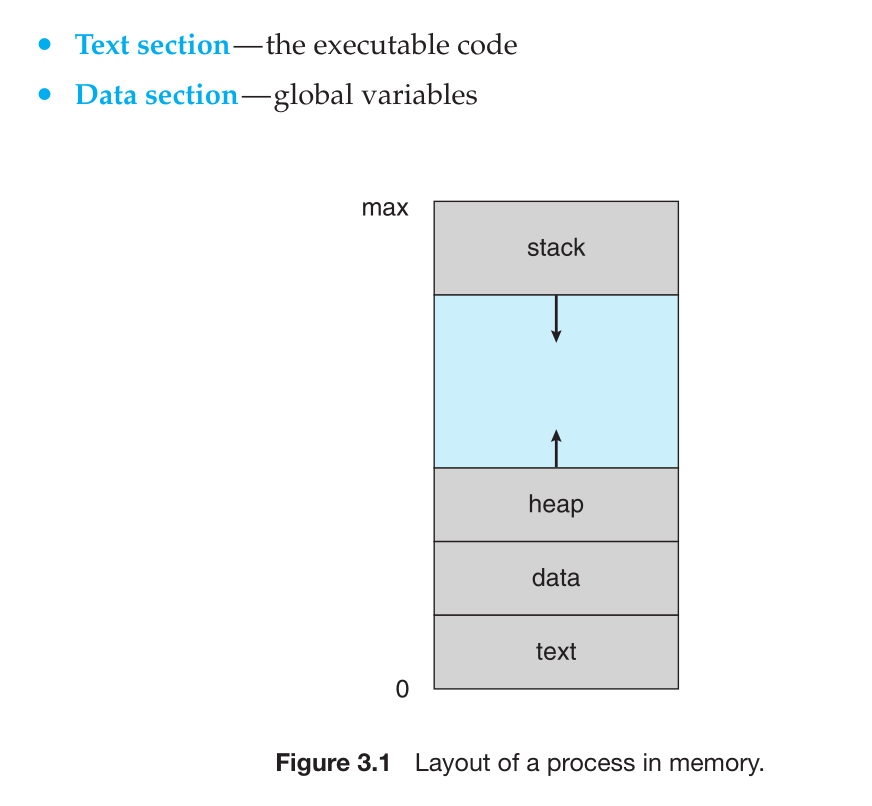

Let's break down each section from the figure:

- **Text Section:** This is the actual executable code of the program. It's the machine instructions that the CPU follows. This section is read-only to prevent a program from accidentally modifying its own instructions.
- **Data Section:** This section holds **global variables**. These are variables that are defined outside of any function and exist for the lifetime of the program.
- **Heap Section:** This is memory that is **dynamically allocated** during program run time. When you use commands like `malloc()` in C or `new` in C++/Java, you are requesting memory from the heap. The heap grows *upwards* (towards higher memory addresses).
- **Stack Section:** The stack is used for temporary data storage when invoking functions. Each time a function is called, an **activation record** (or stack frame) is pushed onto the stack. This frame contains:
  - Function parameters
  - Return addresses (where to go back to when the function is done)
  - Local variables When the function returns, its activation record is popped off the stack. The stack grows *downwards* (towards lower memory addresses).

**Dynamic Behavior:** The sizes of the **text** and **data** sections are fixed when the program starts. However, the **stack** and **heap** can shrink and grow dynamically during execution. As you call more functions, the stack grows. As you allocate more memory, the heap grows. The operating system must ensure that these two sections never collide as they grow towards each other.

#### **Crucial Distinction: Program vs. Process**

This is a fundamental concept:

- A **program** is a **passive** entity. It's just a file on your disk (an executable file) containing a list of instructions. It does *nothing* by itself.
- A **process** is an **active** entity. It has a **program counter** (which tells it the next instruction to execute) and a set of associated resources (like memory, CPU registers, and open files).

A program becomes a process when that executable file is **loaded into memory**. This happens when you double-click its icon or run it from the command line (e.g., `a.out`).

#### **Multiple Processes from One Program**

It's possible to have multiple processes that are all instances of the same program. For example, if you open three different terminal windows, you have three separate processes running the shell program. Even though the **text section** (the executable code) is identical for all of them, each process has its own, separate **data, heap, and stack** sections. This is why one crashed web browser tab doesn't necessarily crash the entire browser—each tab is often a separate process.

#### **Processes as Execution Environments**

A process can itself be a platform for running other code. A perfect example is the **Java Virtual Machine (JVM)**.

When you run `java Program`, the operating system creates a process for the JVM. This JVM process then loads your `Program.class` file and interprets its instructions, executing them on your behalf using native machine instructions. The JVM process is the real process the OS manages, and your Java program runs within this controlled environment.

### **3.1.2 Process State**

A process is not a static entity; it is dynamic. As it executes, its current activity changes, and we describe this using its **state**. The state of a process is defined by what it is currently doing. A process can be in one of several distinct states.

#### **The Five Process States**

Here are the five fundamental states a process can be in:

1. **New:** The process is in the middle of being created. The operating system is setting up its process control block (we'll cover this later) and loading its program into memory.
2. **Running:** Instructions are being executed on a CPU core. This is the state where the process is actively using the processor.
3. **Waiting (or Blocked):** The process cannot proceed because it is waiting for an external event to occur. Common examples include:
   - Waiting for user input (like a keyboard press).
   - Waiting for data to be read from or written to a disk (I/O operation).
   - Waiting for a signal from another process.
4. **Ready:** The process is loaded in memory and is capable of executing, but the operating system has not assigned it to a CPU core yet. It is patiently waiting for its turn to run. There is often a **ready queue** where all ready processes reside.
5. **Terminated:** The process has finished executing. The operating system is in the process of cleaning up its resources (freeing memory, etc.).

**Crucial Point:** On a system with a single CPU core, **only one process can be in the "Running" state at any given instant**. However, many processes can simultaneously be in the "Ready" and "Waiting" states.

#### **The Process State Diagram**

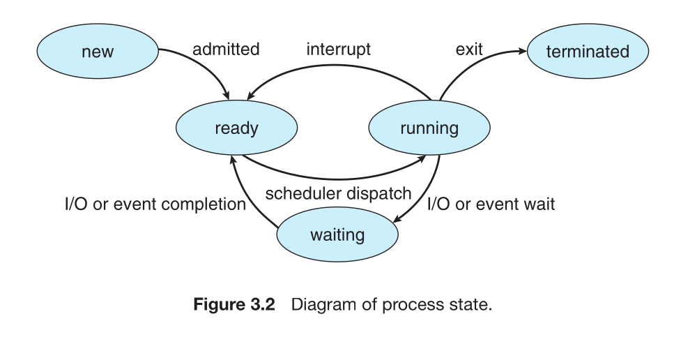

The transitions between these states are best visualized with a diagram. **Go to Figure 3.2** to see the process state transition diagram. Let's walk through what each arrow means:

- **New -> Ready:** When the OS finishes creating the process, it moves it from "New" to the "Ready" queue. This transition is called **admit**.
- **Ready -> Running:** When the operating system's **scheduler** decides it's time for a process to run, it selects a process from the "Ready" state and assigns it to a CPU. This transition is called **dispatch**.
- **Running -> Ready:** A running process can be forced back to the "Ready" state for two main reasons, often related to **interrupts**:
  1. A timer interrupt occurs, meaning the process has used up its maximum allowed time slice (its "turn" on the CPU). This prevents one process from hogging the CPU.
  2. A higher-priority process becomes ready and preempts the current one.
- **Running -> Waiting:** A process voluntarily moves itself to the "Waiting" state when it requests something that takes time and doesn't need the CPU, like an I/O operation (e.g., reading a file). The process is said to **issue a wait** for that event.
- **Waiting -> Ready:** When the event the process was waiting for finally occurs (e.g., the disk read completes), the process moves from "Waiting" back to the "Ready" queue. This is an **I/O or event completion**.
- **Running -> Terminated:** A process moves to the "Terminated" state when it finishes executing its final instruction (voluntarily) or is forcibly killed (involuntarily). It then **exits**.

#### **Memory Layout of a C Program (A Closer Look)**

The previous section gave a general overview of a process's memory layout. Now, let's see how this maps directly to a real C program. The text provides a specific diagram for a C program's memory layout, which refines the general picture from Figure 3.1.

The key differences for a C program are:

- The **data section** is often split into two parts:
  - **Initialized Data:** Contains global variables that were given a starting value (e.g., `int y = 15;`).
  - **Uninitialized Data (often called `bss`):** Contains global variables that were *not* explicitly initialized (e.g., `int x;`). The OS initializes these to zero.
- The **stack** also includes space for the command-line arguments `argc` and `argv` passed to the `main()` function.

**Using the `size` Command:** You can inspect the sizes of these sections in a compiled program using the `size` command. For a program named `memory`, running `size memory` might output:

```
text    data     bss     dec     hex filename
1158     284       8    1450     5aa memory
```

- **text:** The size of the code section (1158 bytes).
- **data:** The size of the *initialized* data section (284 bytes).
- **bss:** The size of the *uninitialized* data section (8 bytes). The term `bss` is a historical acronym for "block started by symbol."
- **dec/hex:** The sum of the three sections in decimal (1450) and hexadecimal (5aa).

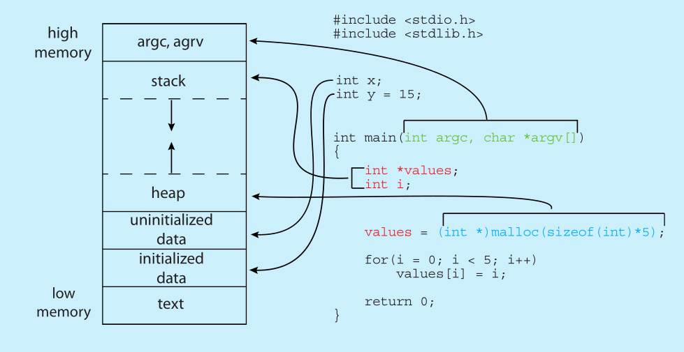

### **3.1.3 Process Control Block**

Now that we know what a process is and the states it can be in, a critical question arises: How does the operating system keep track of all this information for every single process? The answer is the **Process Control Block (PCB)**, which is sometimes also called a *task control block*.

Think of the PCB as a process's **resume or ID card** within the operating system. Each process has exactly one PCB, and the OS uses these PCBs to manage and control all processes. **Go to Figure 3.3** to see a representation of a PCB.

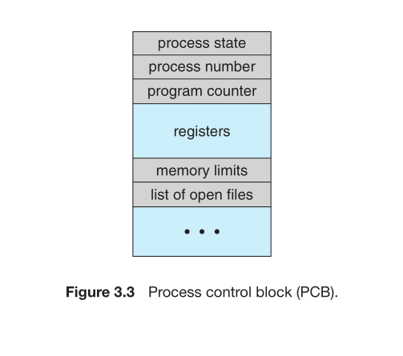

The PCB is a data structure that contains all the information the OS needs to know about a specific process. Let's break down its essential components:

#### **Components of the Process Control Block**

1. **Process State:** This field stores the current state of the process (e.g., running, ready, waiting, etc.), as defined in the previous section.
2. **Program Counter:** This is a crucial piece of information. The PC holds the memory address of the **next instruction** to be executed by this process. When the process is switched out and later resumed, the OS uses this saved address to know where to continue from.
3. **CPU Registers:** This is a set of all the processor registers that the process was using (e.g., accumulators, index registers, stack pointers, general-purpose registers). Like the program counter, these must be saved when the OS interrupts a process so that its entire CPU context can be restored perfectly when it runs again. Together, the Program Counter and CPU Registers form the **hardware state** of the process.
4. **CPU-Scheduling Information:** This is the data the OS scheduler uses to decide which process runs next. It includes:
   - Process priority
   - Pointers to link this PCB to various scheduling queues (like the ready queue)
   - Any other scheduling parameters (we will cover these in detail in Chapter 5).
5. **Memory-Management Information:** This section describes the layout of the process in memory. Its contents depend on the memory system used by the OS (covered in Chapter 9), but it can include:
   - The values of **base and limit registers** (in simple systems).
   - Pointers to **page tables** or **segment tables** (in more advanced virtual memory systems).
6. **Accounting Information:** This is a collection of data for resource usage tracking and billing. It can include:
   - The amount of CPU time the process has used.
   - The total real (wall-clock) time since it started.
   - Time limits.
   - Job or process numbers.
   - Account numbers (for multi-user systems).
7. **I/O Status Information:** This section lists all the resources the process is using for input and output. It includes:
   - The list of I/O devices allocated to the process (e.g., a specific printer).
   - A list of the process's **open files**.

#### **The Role of the PCB**

In summary, the PCB is the **repository for all the data needed to start, stop, and restart a process**. When the OS performs a **context switch** (changing the CPU from one process to another), it must perform these key steps:

1. Save the state of the current running process (its Program Counter and CPU Registers) *into its PCB*.
2. Load the state of the new process (from *its PCB*) into the CPU registers and set the program counter.

This mechanism allows the OS to give the illusion of concurrent execution by transparently switching between processes, using their PCBs as bookmarks.

### **3.1.4 Threads**

The traditional process model we've discussed so far assumes that a process is a single, sequential flow of execution, known as a **thread**. Think of it as a single path of instructions that the CPU follows.

#### **The Limitation of a Single Thread**

In this model, a process can only do one thing at a time. For example, if a word processor is a single-threaded process, it can either:

- Wait for you to type characters, *or*
- Run the spell checker.

It cannot do both simultaneously. If it starts the spell checker, your user interface might freeze until it completes. This is a significant limitation for modern, interactive applications.

#### **The Solution: Multithreading**

Most modern operating systems extend the process concept to allow a single process to contain **multiple threads of execution**. A thread (sometimes called a lightweight process) is a basic unit of CPU utilization within a process. Each thread has its own:

- Thread ID
- Program Counter
- Register set
- Stack

However, all threads within a single process **share the same code, data, and other OS resources**, such as open files and memory space.

This allows a process to perform more than one task at the same time. A **multithreaded** word processor could, for instance:

- Assign one thread to manage user input (keystrokes and mouse clicks).
- Assign a second thread to run the spell checker in the background.
- Assign a third thread to handle auto-saving documents at regular intervals.

This concurrency keeps the user interface responsive even while background tasks are running.

#### **Threads and Hardware**

This feature is especially powerful on **multicore systems**, where the operating system can assign different threads from the same process to different CPU cores, allowing them to run in genuine **parallel**. Even on a single-core CPU, multithreading provides benefits by allowing the CPU to switch between tasks quickly, creating the illusion of simultaneity.

#### **Impact on the Process Control Block (PCB)**

On systems that support threads, the PCB structure we discussed earlier must be expanded. Instead of having just one set of CPU registers and one program counter, the PCB now needs to manage multiple such sets—one for each thread belonging to the process. The PCB becomes a container for the process's shared resources, while also holding or pointing to the individual Thread Control Blocks (TCBs) for each thread.

This requires significant changes throughout the operating system to manage and schedule threads efficiently. Chapter 4 will explore threads in much greater detail.

## **3.2 Process Scheduling**

The core idea behind modern operating systems is to keep the CPU as busy as possible. Two key concepts enable this:

- **Multiprogramming:** The objective is to always have *some* process running at all times to **maximize CPU utilization**. When one process needs to wait for I/O (like a disk read), the OS switches to another process that is ready to run, so the CPU is never idle.
- **Time Sharing:** The objective is to switch the CPU core among processes so frequently that users can interact with each program while it is running. This creates the illusion that multiple programs are executing simultaneously, providing responsiveness.

The component of the operating system that makes this possible is the **process scheduler**. Its job is to select an available process from a set of ready processes and assign it to a CPU core for execution.

A fundamental rule is: **Each CPU core can run only one process at a time.**

#### **Process Scheduling Queues**

To manage which process runs next, the OS uses queues. The two most important queues are illustrated in **Figure 3.4**.

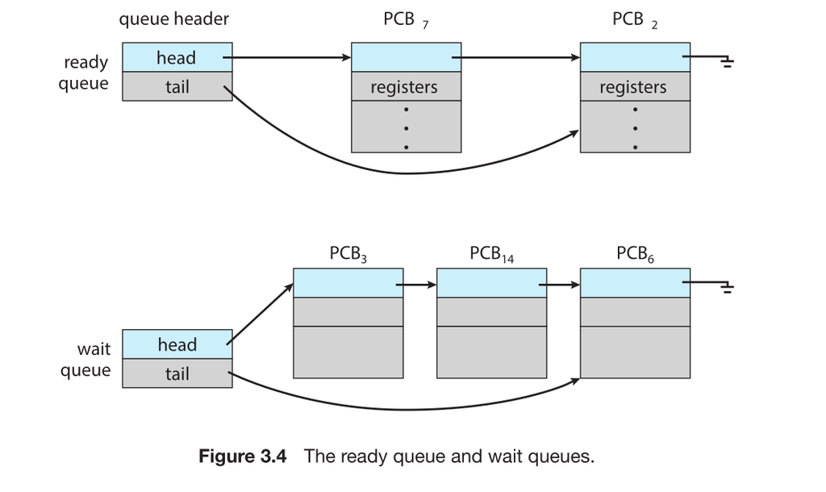

- **The Ready Queue:** This is a queue of all processes that are in the **ready state** (loaded in memory and ready to execute, just waiting for a CPU core). The PCBs of these processes are typically linked together in this queue. The scheduler picks the next process to run from the head of this queue.
- **Wait Queues (or Device Queues):** When a process issues an I/O request, it is moved from the running state to a **waiting state** and its PCB is placed on a wait queue for that specific device (e.g., a disk queue, a keyboard queue). When the I/O operation completes, the process is moved back to the ready queue.

#### **Degree of Multiprogramming**

The number of processes currently residing in memory (and thus capable of being scheduled) is known as the **degree of multiprogramming**.

- On a single-core CPU, only one process can be *running* at any instant, but multiple processes can be in the *ready* and *waiting* states.
- On a multicore system, the number of running processes can be up to the number of cores.
- If there are more ready processes than available cores, the excess processes must wait in the ready queue until a core is free.

#### **Process Behavior: I/O-bound vs. CPU-bound**

An effective scheduler must also consider the general behavior of a process, which generally falls into one of two categories:

- **I/O-bound Process:** This type of process spends more of its time doing I/O operations than computations. These processes typically run for only short bursts before they need to wait for an I/O request to complete (e.g., a text editor waiting for user input, a web server waiting for a network packet). I/O-bound processes typically have many short CPU bursts.
- **CPU-bound Process:** This type of process generates I/O requests infrequently and spends more of its time performing computations (e.g., a scientific calculation, a complex video encoding task). CPU-bound processes typically have few, but very long, CPU bursts.

A good scheduling system maintains a balance: it must give quick, responsive service to I/O-bound processes to keep them from waiting too long, while also ensuring that CPU-bound processes make steady progress.

#### **Process Representation in Linux**

In the Linux operating system, the Process Control Block (PCB) is implemented as a C structure named `task_struct`. You can find this defined in the kernel source code in the file `<include/linux/sched.h>`. This single structure contains all the information the kernel needs to manage a process.

Some of the key fields inside the `task_struct` include:

- `long state;` // stores the current state of the process (running, waiting, etc.)
- `struct sched_entity se;` // contains scheduling information for this process
- `struct task_struct *parent;` // a pointer to the PCB of the process that created this one
- `struct list_head children;` // a list of the PCBs of processes created by this one
- `struct files_struct *files;` // a list of open files for this process
- `struct mm_struct *mm;` // memory management information (like page tables)

The kernel keeps track of all active processes by linking their `task_struct` PCBs together in a **doubly linked list**. It also maintains a special pointer, `current`, which points to the `task_struct` of the process currently executing on the CPU.

For example, if the kernel needs to change the state of the currently running process, it can simply execute: `current->state = new_state;`

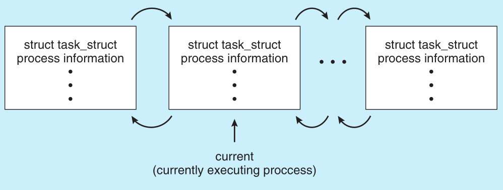

### **3.2.1 Scheduling Queues**

To manage the many processes in various states, the operating system uses a series of queues. Think of these as waiting lines for different resources.

#### **The Ready Queue**

As processes enter the system, they are placed into the **ready queue**. This queue holds all processes that are loaded in memory and ready to execute, but are waiting for their turn on a CPU core.

- **Implementation:** This queue is typically stored as a **linked list** of Process Control Blocks (PCBs).
- **Structure:** There is a **ready-queue header** that contains a pointer to the first PCB in the list. Each PCB in the list has a pointer field that points to the next PCB in the ready queue.

#### **Wait Queues**

The system also includes other queues, known collectively as **wait queues** (or device queues). A process is moved to a wait queue when it cannot continue execution until a specific event occurs.

- **Common Reason:** The most common reason is an **I/O request**. For example, if a process needs to read data from a disk, it must wait because devices like disks run much slower than the CPU. Rather than letting the CPU sit idle, the OS moves the process to the appropriate **I/O wait queue** until the data is available.

#### **The Queueing Diagram**

The flow of processes through these queues is best visualized with a queueing diagram. **Go to Figure 3.5** for a representation of process scheduling.

In this diagram:

- The **rectangles** represent the queues (the ready queue and various wait queues).
- The **circles** represent the resources that serve the queues (the CPU and I/O devices).
- The **arrows** indicate the flow of processes from one state to another.

#### **The Lifecycle of a Process in the Queues**

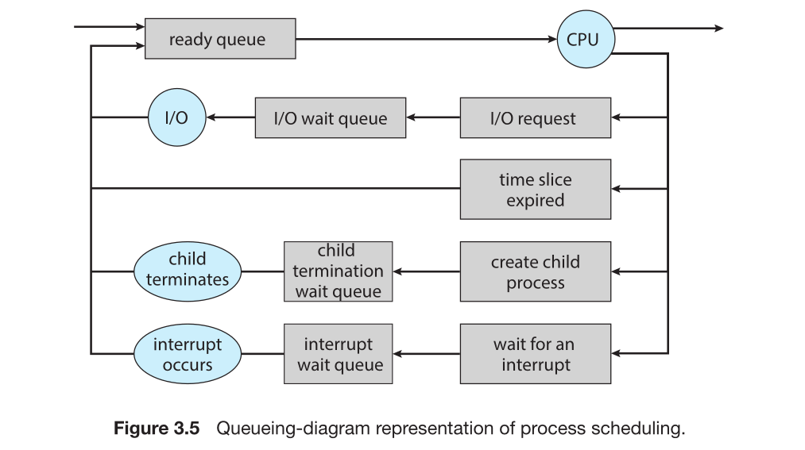

Let's trace the path a process takes through the system, following Figure 3.5:

1. A **new process** is initially put into the **ready queue**.
2. It waits there until it is **dispatched** (selected) by the CPU scheduler and assigned to a CPU core.
3. Once the process is **executing** on the CPU, one of several events can occur:
   - **The process issues an I/O request:** It is immediately moved from the CPU to the relevant **I/O wait queue**. (Path: CPU -> "I/O request" -> I/O wait queue)
   - **The process creates a child process and waits for it:** It is moved to a **wait queue** until the child process terminates. (Path: CPU -> "create child process" -> child termination wait queue)
   - **An interrupt occurs or the time slice expires:** The process is forcibly removed from the CPU and placed back into the **ready queue** to wait for its next turn. (Path: CPU -> "time slice expired" -> ready queue)
4. For processes in wait queues (the first two cases), the transition back to readiness happens when the event they were waiting for occurs:
   - An I/O operation completes, moving the process from the I/O wait queue back to the ready queue. (Path: I/O wait queue -> "I/O" -> ready queue)
   - A child process terminates, moving the waiting parent from the child termination wait queue back to the ready queue.

This cycle of moving between the **ready queue**, the **CPU**, and various **wait queues** continues for the entire life of the process.

5. When the process **terminates**, it is removed from all queues, and its PCB and all other resources are deallocated by the operating system.

### **3.2.2 CPU Scheduling**

We've seen how processes move between queues. The central component that manages the "ready queue -> CPU" transition is the **CPU scheduler** (often just called the *scheduler*).

#### **The Role of the CPU Scheduler**

The core responsibility of the CPU scheduler is to select one process from the **ready queue** and allocate a CPU core to it. This decision is called a **scheduling decision**.

This selection process needs to happen very frequently for two key reasons:

1. **I/O-bound Processes:** These processes may only execute for a few milliseconds before they issue an I/O request and are moved to a wait queue. The scheduler must be ready to quickly pick a new process to run.
2. **Time Sharing and Fairness:** Even a **CPU-bound process** is not allowed to keep the CPU for as long as it wants. To maintain system responsiveness and fairness, the operating system uses timer interrupts to **forcibly remove** the CPU from a running process after a specific time interval (called a **time slice** or **quantum**). When this time slice expires, the process is moved back to the ready queue, and the scheduler immediately runs to select the next process.

Because of this, the CPU scheduler is one of the most frequently executed parts of the OS, running at least once every 100 milliseconds, and often much more.

#### **Intermediate Scheduling and Swapping**

Beyond the short-term CPU scheduler, some operating systems employ an intermediate form of scheduling. This is not about deciding which process runs next on the CPU, but about deciding which processes are allowed to be in memory and thus eligible for the ready queue.

The key idea is that sometimes it's beneficial to **reduce the degree of multiprogramming** (the number of processes in memory). This is done through a mechanism called **swapping**.

- **Swapping Out:** The OS can decide to remove a process completely from memory. It saves the entire process's image (its code, data, stack, and PCB state) to a special area on the disk (called the **swap space**). This process is now no longer in the ready queue and is not competing for the CPU.
- **Swapping In:** Later, the OS can load the swapped-out process from disk back into memory, restoring its status so it can continue execution from where it left off.

**Why is Swapping Necessary?** Swapping is typically used as a memory management technique. It becomes necessary when the system has **overcommitted memory** (i.e., there are more processes in memory than physical RAM can comfortably hold). By swapping out some idle processes, the OS frees up physical memory for active processes. We will discuss swapping in detail in **Chapter 9**.

### **3.2.3 Context Switch**

When the CPU scheduler decides to stop running one process and start running another, a fundamental operation must occur: the **context switch**. This is the mechanism that makes multitasking possible.

#### **What is a Context Switch?**

A context switch is the process of saving the state of the currently running process (the "old" process) and loading the saved state of the new process to run.

- **The "Context":** The context of a process is all the information the CPU needs to resume that process from exactly where it left off. This is represented in the process's **PCB** and includes:
  - The value of all **CPU registers** (including the program counter).
  - The process state.
  - Memory-management information (like page table pointers).
- **The Operation:** The core task is a **state save** of the old process's context into its PCB, followed by a **state restore** of the new process's context from its PCB.

**Go to Figure 3.6** for a diagram illustrating a context switch between two processes, P0 and P1.

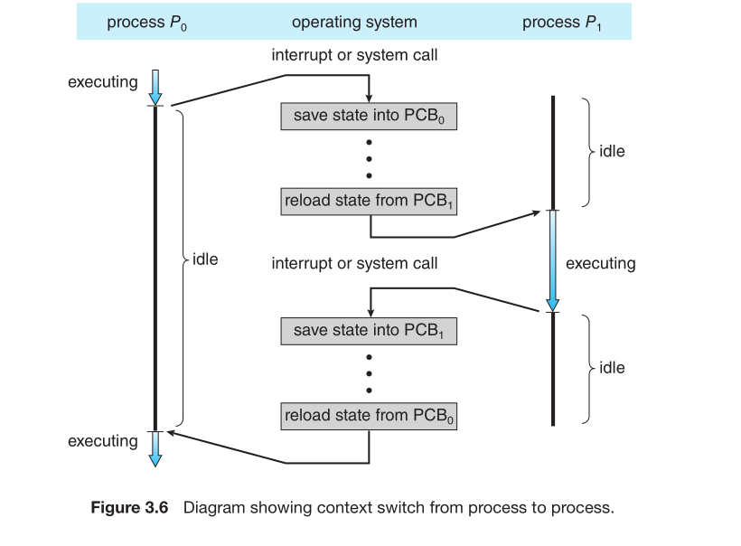

#### **Context Switch Overhead**

It is crucial to understand that **context-switch time is pure overhead**. While the CPU is busy saving and restoring contexts, it is not executing any user instructions or performing useful work for any process. The system's performance depends on making context switches as fast as possible.

- **Typical Speed:** A context switch typically takes several microseconds.
- **Factors Influencing Speed:**
  - **Hardware Support:** This is the biggest factor. Some processors have features like multiple register sets. This allows a context switch to happen by simply changing a hardware pointer to the current register set, which is extremely fast. If there are more processes than register sets, the OS must fall back to copying data to and from memory.
  - **Memory Speed:** The speed of the RAM.
  - **Number of Registers:** The more data that must be copied, the longer it takes.
  - **OS Complexity:** More complex operating systems, especially those using advanced memory management (like paging, covered in Chapter 9), have more work to do during a context switch (e.g., switching page tables, flushing translation lookaside buffers (TLBs)).

#### **Multitasking in Mobile Systems**

Mobile operating systems like iOS and Android handle process scheduling with additional constraints, primarily to conserve battery life.

**iOS (Apple):**

- **Early versions** were very restrictive. Only one user application could run in the **foreground** (the app on the screen). All other user apps were **suspended** (not scheduled for CPU time).
- Starting with **iOS 4**, a limited form of multitasking was introduced, allowing a single foreground app to run concurrently with multiple **background** apps (in memory but not on the display). The API allowed certain app types (like music players) to perform limited tasks in the background.
- As hardware improved (more memory, multiple cores, better batteries), iOS supported richer multitasking, such as **split-screen** on iPads, which allows two foreground apps to run simultaneously.

**Android:**

- Android has always supported multitasking and does not restrict which applications can run in the background.
- However, if a background app needs to perform work, it must use a **service**. A service is a separate application component that runs on behalf of the background process without a user interface.
- **Example:** A music streaming app uses a service. When you switch to another app, the main application may be suspended, but the service continues running to send audio data to the device driver. This design is efficient because services have a small memory footprint.

## **3.3 Operations on Processes**

In a modern operating system, processes are dynamic. They can be created and terminated on the fly. This section covers the mechanisms for these fundamental operations.

### **3.3.1 Process Creation**

A process can create other new processes during its execution. This leads to a hierarchical relationship:

- **Parent Process:** The creator process.
- **Child Process:** The new process that was created.

Each child process can, in turn, create more processes, forming a **tree** (or hierarchy) of processes.

Operating systems like UNIX, Linux, and Windows identify each process by a unique integer known as a **process identifier (pid)**. The kernel uses the pid as a key to access all of a process's attributes in its PCB.

**Go to Figure 3.7** to see a typical process tree on a Linux system.

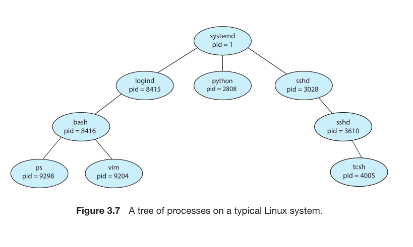

Let's analyze this figure:

- The root of the tree is the **`systemd`** process, which always has **pid = 1**. This is the first user process started when the system boots, and it is the ultimate parent of all other user processes.
- `systemd` creates child processes to manage system services. In the figure, it has created:
  - **`logind` (pid 8415):** Manages users who log on directly to the system.
  - **`sshd` (pid 3028):** Manages remote connections via Secure Shell (SSH).
- These service processes, in turn, create children for user sessions:
  - `logind` has created a **`bash` shell** (pid 8416) for a logged-in user.
  - The user, working in the `bash` shell, has launched two child processes: the **`ps`** command (pid 9298) and the **`vim`** editor (pid 9204).
  - Similarly, the `sshd` process has created a child `sshd` (pid 3610) to handle a specific remote connection, which then launched a **`tcsh`** shell (pid 4005) for the remote user.

#### **The `init` and `systemd` Processes**

There is an important historical note here. Traditional UNIX systems used a process called **`init`** (System V init) as the root parent process with pid 1. Linux initially adopted this.

Modern Linux distributions have replaced `init` with **`systemd`**. While both serve as the initial root process, `systemd` is more flexible and provides a wider range of services than the traditional `init` system.

You can view active processes on UNIX/Linux using the `ps` command. The command `ps -el` lists complete information for all processes. You can trace the parent-child relationships to build a process tree in your mind. Linux also provides the `pstree` command, which visually displays the entire process tree.

#### **Resource Sharing in Process Creation**

When a parent creates a child process, a critical question is: how are resources handled? The child process needs resources (CPU time, memory, files, I/O devices) to run. There are two general approaches:

1. The child process may obtain its resources **directly from the operating system**.
2. The child process may be constrained to use only a **subset of the parent's resources**.

The parent can manage resources for its children in different ways:

- **Partitioning:** The parent divides its resources among its children.
- **Sharing:** The parent and children share some resources (like memory segments or open files).

Restricting a child to a subset of the parent's resources is a important safety and stability measure. It prevents any single process from overloading the entire system by creating too many resource-hungry child processes.

Beyond just allocating resources, a parent process can also pass specific data or resources to its child to define its task.

- **Passing Initialization Data:** The parent can give the child input data. For example, a parent process could create a child whose job is to display a file. The parent would pass the filename (e.g., `hw1.c`) to the child. The child then uses that name to open the file and display it.
- **Passing Resources:** Some operating systems allow the parent to pass actual resources. In the same example, the parent could open the file `hw1.c` and the terminal device, and then pass these two open files to the child. The child's job then simplifies to just copying data from the input file to the output terminal file.

#### **Execution and Address Space Possibilities**

When a process creates a child, the OS must decide two things:

1. **Execution Flow:**
   - The parent and child execute **concurrently**.
   - The parent **waits** for some or all of its children to finish before resuming.
2. **Address Space:**
   - The child is a **duplicate** of the parent process (same program and data).
   - The child has a **brand new program** loaded into it.

#### **Process Creation in UNIX/Linux**

UNIX and Linux provide a classic and clear model for process creation using two key system calls: `fork()` and `exec()`.

**Step 1: Creating a Copy with `fork()`**

- A new process is created by the **`fork()`** system call.
- The key effect of `fork()` is that the **child process is an exact duplicate of the parent's address space**. This means both processes have the same code, data, heap, and stack at the moment of creation.
- Both the parent and the child start executing from the instruction *immediately after* the `fork()` call.
- The only way to tell them apart is by the return value of `fork()`:
  - In the **child process**, `fork()` returns **0**.
  - In the **parent process**, `fork()` returns the **child's positive process identifier (pid)**.
  - If `fork()` fails, it returns -1.

**Step 2: Loading a New Program with `exec()`**

- After forking, one of the processes (often the child) typically uses an **`exec()`** system call.
- `exec()` **replaces the current process's memory space with a brand new program**. It loads the binary file of the new program, destroying the old memory image (the one that contained the `exec()` call).
- Because it replaces the entire address space, a successful call to `exec()` **does not return**; the process begins executing the new program's first instruction.

**Step 3: Waiting for the Child with `wait()`**

- The parent process, after creating a child, can use the **`wait()`** system call.
- `wait()` causes the parent to be **suspended (blocked)** until one of its children terminates.
- Once the child terminates, the parent resumes execution from the point after the `wait()` call.

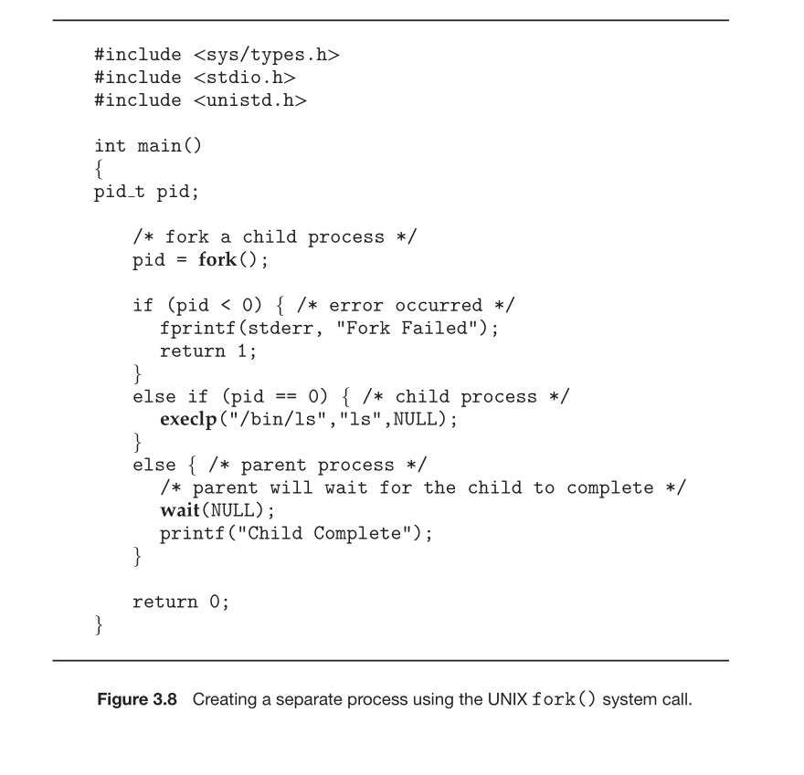

#### **Illustrative Example**

**Go to Figure 3.8** to see a C program that demonstrates this entire flow. Let's trace through it:

1. The program starts as a single process.
2. `pid = fork();` is executed. Now there are two identical processes.
3. Both processes check the value of `pid`:
   - **In the Child Process (`pid == 0`):**
     - It calls `execlp("/bin/ls", "ls", NULL);`.
     - This `exec()` call replaces the child's memory with the `/bin/ls` program (the directory lister).
     - The child executes `ls` and then terminates.
   - **In the Parent Process (`pid > 0`, and is the child's actual PID):**
     - It calls `wait(NULL)`. This blocks the parent, putting it to sleep.
     - When the child finishes, the parent wakes up.
     - The parent then prints "Child Complete" and exits.

This sequence of events is also illustrated in **Figure 3.9**. The child inherits attributes from the parent but then becomes a completely different program, while the parent waits for it to finish its task.

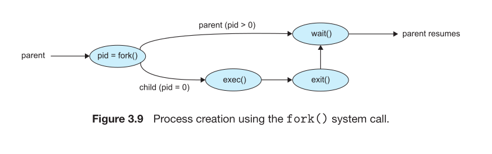

#### **The `fork()` Without `exec()` Scenario**

It's important to note that a child process is not *required* to call `exec()` after a `fork()`. The child can choose to continue executing the same program as the parent. In this scenario:

- The parent and child become **concurrent processes running the exact same code**.
- Because `fork()` creates a full copy of the address space, **each process has its own separate copy of all data**. Changes made to variables in the child will not affect the parent, and vice-versa.

This allows for a design where a single program can split into two parallel execution paths, each performing different tasks based on the return value of `fork()`.

#### **Process Creation in Windows**

The Windows operating system uses a different model for process creation, centered on the **`CreateProcess()`** function.

While `CreateProcess()` serves the same purpose as `fork()` (a parent creates a child), its behavior and usage are quite different:

| Feature | UNIX/Linux (`fork()` and `exec()`) | Windows (`CreateProcess()`) |
| --- | --- | --- |
| **Core Action** | Creates a duplicate copy of the parent. | Creates a new process and loads a specified program into it. |
| **Address Space** | Child inherits a copy of the parent's address space. | Child starts with the address space of a new program. |
| **System Calls** | Two steps: `fork()` (create copy) then `exec()` (load program). | One step: `CreateProcess()` does both at once. |
| **Parameters** | `fork()` takes no parameters. | `CreateProcess()` requires at least ten parameters. |

**Key Differences Explained:**

- **Inheritance vs. Specification:** The UNIX model is based on inheritance (the child gets everything the parent has). The Windows model is based on specification (the parent must specify exactly what program the child will run from the start).
- **Simplicity vs. Control:** The UNIX `fork()` is a simple, parameter-less call that is very powerful. The Windows `CreateProcess()` is a single, more complex function that gives the programmer fine-grained control over the new process's attributes from the moment of its creation.

**Go to Figure 3.10** to see an example of a C program using `CreateProcess()`. This program creates a child process that immediately loads the `mspaint.exe` application (Microsoft Paint). The code uses default values for most of the ten parameters required by `CreateProcess()`.

For those who need to work deeply with Windows processes, further study of the Windows API and the specific parameters of `CreateProcess()` is recommended.

#### **Process Creation in Windows (Detailed Explanation)**

The previous section introduced the `CreateProcess()` function. Now, let's break down its parameters and the accompanying program in detail.

**Go to Figure 3.10** to see the C program that creates a process using the Windows API.

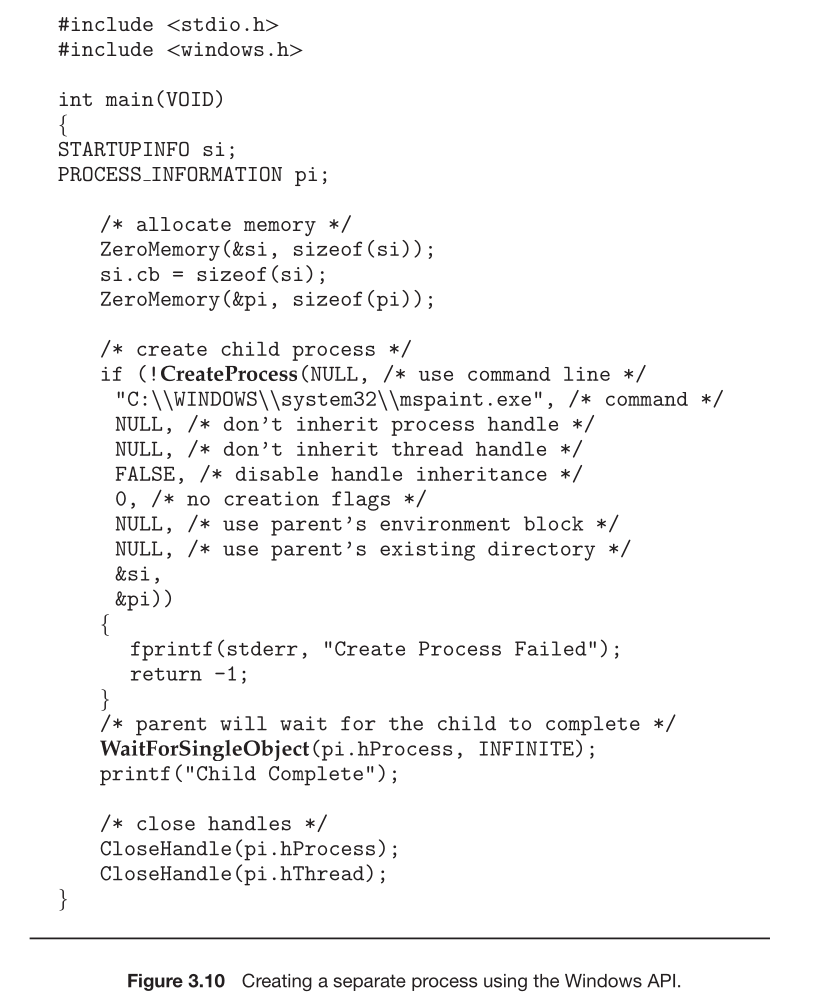

##### **Key Data Structures for `CreateProcess()`**

The `CreateProcess()` function uses two main structures to manage information:

1. **`STARTUPINFO` Structure:** This structure allows the parent to specify many properties of the new child process's user interface and standard handles. This includes:
   - The window's size and position on the screen.
   - The window's appearance (e.g., should it be shown or hidden?).
   - Handles for standard input, output, and error files. In the provided code, `ZeroMemory(&si, sizeof(si));` is used to allocate and initialize the memory for this structure, and `si.cb = sizeof(si);` sets the size of the structure, which is a required step.
2. **`PROCESS_INFORMATION` Structure:** After `CreateProcess()` successfully creates the new process, it returns information about that process back to the parent by filling in this structure. It contains:
   - A **handle** to the new process (`hProcess`).
   - A **handle** to the new process's primary thread (`hThread`).
   - The **process identifier (pid)** of the new process (`dwProcessId`).
   - The **thread identifier** of the new process's primary thread (`dwThreadId`).

##### **Analyzing the `CreateProcess()` Call**

Let's examine the call to `CreateProcess()` in the code:

- **`NULL`:** The first parameter (application name) is `NULL`. This means we are not explicitly specifying the application name.
- **`"C:\\WINDOWS\\system32\\mspaint.exe"`:** The second parameter (command line) specifies the full path to the executable file to be loaded. Since the first parameter is `NULL`, the system uses this command line to find and load the `mspaint.exe` application (Microsoft Paint).
- **`NULL, NULL, FALSE`:** The next three parameters concern handle inheritance. We are specifying that the child process should NOT inherit handles from the parent process.
- **`0, NULL, NULL`:** These parameters specify no creation flags, use the parent's environment block, and use the parent's current directory.
- **`&si, &pi`:** The final two parameters are pointers to the `STARTUPINFO` and `PROCESS_INFORMATION` structures we prepared earlier.

##### **The Parent's Wait and Cleanup**

- **`WaitForSingleObject(pi.hProcess, INFINITE);`:** This is the Windows equivalent of the UNIX `wait()` system call. The parent process calls this function and passes it the handle to the child process (`pi.hProcess`). The `INFINITE` parameter means the parent will wait indefinitely until the child process terminates. This blocks the parent, just like `wait()` does in UNIX.
- **`CloseHandle(pi.hProcess);` and `CloseHandle(pi.hThread);`:** In Windows, when you are done using a resource like a process or thread handle, you must explicitly close it to avoid resource leaks. This is a crucial cleanup step.

This entire flow is the Windows way of achieving what the UNIX program in **Figure 3.8** and the associated diagram in **Figure 3.9** accomplish: creating a child process, waiting for it to finish, and then continuing.

### **3.3.2 Process Termination**

This section explains all the ways a process ends and how the operating system cleans up afterward.

#### **How a Process Ends Voluntarily**

A process normally terminates when it has done its job. It executes its final line of code and then explicitly asks the operating system to delete it by invoking the `exit()` system call.

- **What happens during `exit()`?** The operating system performs a cleanup routine. It deallocates all resources that were assigned to the process. This includes:
  - Physical and Virtual Memory
  - Open Files
  - I/O Buffers
- **Communication with the Parent:** The process can return a status value (like an integer) to its parent process. The parent retrieves this status using the `wait()` system call, which we'll discuss in more detail soon.

#### **Involuntary Termination: When a Parent Kills a Child**

A process doesn't always get to finish on its own terms. Termination can also be forced, usually by its **parent process**, using a system call like `TerminateProcess()` in Windows.

- **Why is this restricted?** This power is typically restricted to the parent process. If any process could terminate any other, a user or a buggy application could arbitrarily kill another user's processes, causing chaos.
- **How does the parent know which process to kill?** When a parent creates a child process, the operating system gives the parent the unique **process identifier (PID)** of the new child.

The textbook lists several reasons a parent might terminate a child:

1. **Resource Overuse:** The child is using more resources (CPU time, memory) than it was allocated.
2. **Task No Longer Needed:** The job the child was created for is no longer required.
3. **Parent is Exiting:** On many operating systems, if a parent process terminates, all of its children must be terminated as well.

This last scenario leads to an important concept called **cascading termination**. If a process terminates, the OS will automatically terminate all of its children, and those children's children, and so on, in a cascading manner.

#### **The Technical Details in UNIX/Linux**

Let's look at the specific system calls used in UNIX and Linux systems.

- **The `exit()` System Call:** A process calls `exit()` to end itself. The parameter it passes (e.g., `exit(1)`) is the **exit status** that its parent can read. In C programs, even if you don't explicitly call `exit()`, the C run-time library will call it for you when the `main()` function returns.
- **The `wait()` System Call and Zombie Processes:** This is a crucial concept for process management.
  - A parent uses `wait(&status)` to pause its own execution until one of its child processes terminates.
  - The `wait()` call gives the parent the child's **exit status** and its **process identifier (PID)**.

  **What is a Zombie Process?** When a process terminates, its resources are freed, but its entry in the **process table** must remain. This entry stays until the parent calls `wait()` to read the child's exit status. A process in this state—terminated but still having an entry in the process table—is called a **zombie process**.
  - All processes become zombies briefly upon termination.
  - The zombie is finally "reaped" (its process table entry is freed) when the parent calls `wait()`.
- **Orphan Processes and Their Adoption** What happens if a parent terminates *without* calling `wait()` on its children? The children become **orphan processes**.

  Traditional UNIX systems solve this by having the `init` process (the very first process, PID 1, which you learned about in Section 3.3.1) automatically become the new parent of all orphaned processes. The `init` process periodically calls `wait()`, which cleans up any zombies left behind by their original parent.

  In modern Linux systems, the `init` process has largely been replaced by `systemd`. However, `systemd` (or another designated process) still performs this same crucial role of adopting orphan processes and reaping them to prevent permanent zombies.

#### **3.3.2.1 Android Process Hierarchy**

This section explains how Android, an operating system for mobile devices with limited resources like memory, decides which processes to terminate when it needs to free up system resources. Unlike a desktop OS that might have more flexibility, Android cannot afford to terminate processes arbitrarily. Instead, it uses a strict **importance hierarchy**.

##### **The Need for a Hierarchy**

Because of constraints like limited memory, Android must sometimes terminate existing processes to make resources available for new or more important processes. The goal is to do this in a way that is least disruptive to the user. It does this by ranking processes by importance and terminating them from least important to most important.

##### **The Android Process Importance Hierarchy**

Here are the process classifications, listed from most important to least important:

1. **Foreground Process:** This is the most important type of process. It is the current process visible on the screen, representing the application the user is actively interacting with right now (e.g., the app you have open and are typing in). Terminating this would directly interrupt the user.
2. **Visible Process:** This is a process that is not in the direct foreground but is still performing an activity that the user is aware of. A classic example is a navigation app that is running and displaying your route on a portion of the screen while another app is in the foreground. The user can see its output, so it has high importance.
3. **Service Process:** This is a process that is running a background service, but the service is performing an activity that is "apparent" to the user. The textbook gives the example of **streaming music**. Even though you're not in the music app, you know the service is running because you can hear the music. Terminating it would be noticeable.
4. **Background Process:** This is a process that is performing an activity, but it is not apparent to the user at the moment. An example is an app that you used earlier but have since navigated away from, and it's not doing anything critical. The user wouldn't immediately notice if this process was terminated.
5. **Empty Process:** This is the least important type of process. It is a cache of a previously used application that holds no active components. It's kept in memory only to speed up a future relaunch of the app. Terminating this has no negative effect on the user experience.

##### **How Termination Works**

When system resources must be reclaimed, Android will terminate processes in this exact order of increasing importance:

- It will first terminate **Empty processes**.
- If more resources are needed, it will then terminate **Background processes**.
- It will continue this pattern, moving up the hierarchy, until enough resources are freed.

##### **Process Ranking and Lifecycle**

The operating system is responsible for assigning each process the highest ranking it qualifies for.

- **Example:** If a process is both providing a service (like music playback) *and* is partially visible on the screen, it will be assigned the more-important **Visible** classification, not the **Service** classification.

Furthermore, Android development guidelines require apps to follow specific rules for their **process life cycle**. When these guidelines are followed, the state of a process (like where you were in a game or what you had typed in a note) is saved *before* the process is terminated. If the user navigates back to the application later, the process can be restarted and resumed from its saved state, making the termination and relaunch much smoother and less noticeable.

## **3.4 Interprocess Communication**

This section introduces the concept of how processes can work together, which is a fundamental part of modern operating systems.

### **Independent vs. Cooperating Processes**

Processes running at the same time in an OS can be categorized into two types:

- **Independent Process:** A process that does not share data with any other process. It operates in isolation and is not affected by, nor can it affect, the execution of other processes.
- **Cooperating Process:** A process that can interact with other processes. It can affect or be affected by them. Any process that shares data with another is automatically a cooperating process.

### **Why Allow Process Cooperation?**

There are three primary reasons for enabling processes to cooperate:

1. **Information Sharing:** Several applications might need access to the same data. A common example is your computer's **clipboard**; when you copy and paste, multiple applications are accessing the same piece of information. The OS must provide an environment for this concurrent access.
2. **Computation Speedup:** To make a large task run faster, we can break it down into smaller subtasks that run in parallel. **Important Note:** This provides a real speedup only if the computer has multiple processing cores (CPUs), allowing true parallel execution. Otherwise, the tasks are just switching on a single core.
3. **Modularity:** We can design a system in a modular way, dividing system functions into separate, cooperating processes (or threads). This makes the system easier to build, maintain, and extend.

### **The Two Models of Interprocess Communication (IPC)**

For cooperating processes to exchange data, we need a mechanism called **Interprocess Communication (IPC)**. There are two fundamental models for this:

1. **Shared Memory:** In this model, a region of memory is set up that can be accessed by all the cooperating processes. Processes exchange information by simply **reading from and writing to** this shared region. It's like a shared whiteboard that multiple people can read and write on.
2. **Message Passing:** In this model, processes communicate by sending and receiving discrete **messages** to/from each other. This communication typically goes through the operating system's kernel. It's like passing notes between people; the note is handed from one to the other.

**Go to Figure 3.11** in your textbook. This figure contrasts the two models visually:

- In diagram (a), **Shared Memory**, Process A and Process B both have access to a common block of memory. The data exchange happens directly in this space.
- In diagram (b), **Message Passing**, Process A and Process B send messages (m0, m1, etc.) to each other via a message queue managed by the kernel.

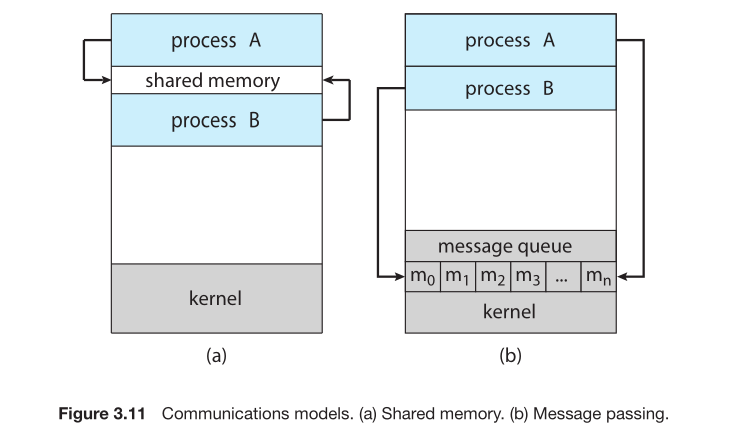

### **Comparing Shared Memory and Message Passing**

Both models are common, and many operating systems support both.

- **Advantages of Message Passing:**
  - It is useful for exchanging smaller amounts of data.
  - It is easier to implement because the kernel handles the communication, avoiding complex conflict scenarios.
  - It can be extended to **distributed systems** (where processes are on different computers connected by a network) much more easily than shared memory.
- **Advantages of Shared Memory:**
  - It can be **faster** once it's set up. Message passing requires a **system call** (and therefore kernel intervention) for *every* single message sent or received, which is computationally expensive. In shared memory, system calls are needed only to *establish* the shared region. After that, processes read and write to the shared memory just like normal memory accesses, without any need for the kernel's help, making it very fast.

The following sections, **3.5** and **3.6**, will explore shared-memory and message-passing systems in more detail.

### **MULTIPROCESS ARCHITECTURE—CHROME BROWSER**

This section explains how modern web browsers, specifically Google Chrome, use a multiprocess architecture to solve problems of stability, security, and performance.

#### **The Problem with Single-Process Browsers**

Websites use active content like JavaScript, Flash, and HTML5 to create dynamic experiences. However, this code can contain bugs that cause a web browser to become slow or even crash entirely.

This becomes a major issue with **tabbed browsing**, where a single browser instance displays multiple websites in different tabs. In a traditional, single-process browser, all tabs run within the same process.

- **The Critical Flaw:** If a website in *one tab* crashes, it takes down the *entire browser process*, causing *all your tabs* to crash. This is a poor user experience.

#### **Chrome's Solution: A Multiprocess Architecture**

Google's Chrome browser was designed to fix this problem by using multiple cooperating processes. It separates different functions into distinct process types:

1. **The Browser Process:**
   - This is the **main manager** of the entire application.
   - It is responsible for the user interface (the address bar, buttons, tabs themselves) and for disk and network input/output (I/O).
   - **Only one browser process exists** for the entire Chrome application.
2. **The Renderer Processes:**
   - These processes contain the logic for **rendering (drawing)** a web page. They interpret and execute the HTML, JavaScript, and CSS for a site.
   - **A general rule is one renderer process per website tab.** This means if you have ten tabs open, you likely have ten active renderer processes.
   - This is the core of the solution.
3. **The Plug-in Processes:**
   - A separate process is created for each type of plug-in (like Adobe Flash or Apple QuickTime).
   - This isolates the often-buggy and vulnerable plug-in code from the rest of the browser.

[figure not shown]

#### **Advantages of This Multiprocess Design**

This architecture provides two massive benefits:

1. **Stability (Crash Isolation):**
   - Because each website runs in its own **isolated renderer process**, if one website crashes, only that specific renderer process dies.
   - The **browser process** and all other **renderer processes** for your other tabs remain completely unaffected. You might see an "Aw, Snap!" error on one tab, but all your other tabs continue to work perfectly.
2. **Security (The Sandbox):**
   - Each renderer process runs in a restricted environment called a **sandbox**.
   - The sandbox **limits the renderer's access** to sensitive system resources like your disk and network. Even if a malicious website exploits a bug in the renderer, the sandbox prevents the attack from doing significant harm to your system, as the compromised process has very limited permissions.

## **3.5 IPC in Shared-Memory Systems**

This section dives into the details of how processes communicate by sharing a common block of memory. This is a powerful but complex mechanism that requires careful setup and coordination.

### **Establishing Shared Memory**

For processes to use shared memory, they must first establish a region of memory that they all can access. Here is the typical process:

1. One process creates a **shared-memory segment**. This segment resides within the address space of the creating process.
2. Any other process that wants to communicate must then **attach** this same shared-memory segment to its own address space.
3. Normally, the operating system strictly enforces memory isolation, preventing one process from accessing another's memory. Using shared memory requires that the processes explicitly **agree to remove this restriction**.

Once the shared region is set up, processes can exchange information by directly **reading and writing data** to these shared areas. The operating system is no longer involved in the actual data transfer. The processes themselves are responsible for:

- Deciding the **format** of the data.
- Deciding the **location** of data within the shared segment.
- **Ensuring they do not write to the same location at the same time**, which would cause data corruption.

### **The Producer-Consumer Problem**

A classic example that demonstrates cooperating processes is the **producer-consumer problem**. This is a common paradigm in computing.

- A **producer** process generates information or data.
- A **consumer** process uses or processes that data.

**Real-world examples:**

- A **compiler** (producer) generates assembly code that is consumed by an **assembler** (consumer).
- A **web server** (producer) provides HTML files and images that are consumed by a **client web browser** (consumer).

### **Solving with a Shared Buffer**

To allow the producer and consumer to run concurrently, we need a **buffer**—a temporary storage area—that resides in shared memory. The producer adds items to the buffer, and the consumer removes them.

**Crucially, the processes must be synchronized.** The consumer must not try to take an item from an empty buffer, and (in a bounded system) the producer must not try to add an item to a full buffer.

There are two types of buffers:

- **Unbounded Buffer:** Has no practical size limit. The consumer might have to wait for new items, but the producer can always produce.
- **Bounded Buffer:** Assumes a fixed buffer size. This is the more common and practical scenario. Here, the consumer must wait if the buffer is empty, and the producer must wait if the buffer is full.

### **The Bounded-Buffer Solution in Detail**

Let's examine a shared-memory implementation of a bounded buffer. The following variables reside in the shared memory region:

```
#define BUFFER_SIZE 10

typedef struct {
    . . .  // This struct defines what an "item" is
} item;

item buffer[BUFFER_SIZE];
int in = 0;
int out = 0;
```

The buffer is a circular array. It is managed with two logical pointers (indices):

- `in`: Points to the **next free position** in the buffer where a producer can put a new item.
- `out`: Points to the **first full position** in the buffer from which a consumer can take an item.

**How to determine the buffer's state:**

- The buffer is **empty** when `in == out`.
- The buffer is **full** when `((in + 1) % BUFFER_SIZE) == out`. (This scheme leaves one empty slot to distinguish between the full and empty conditions).

**The Producer Process** The producer has a local variable `next_produced` where it creates a new item.

```
item next_produced;
while (true) {
    /* produce an item in next_produced */

    // This while-loop is the synchronization check.
    // It spins and does nothing if the buffer is full.
    while (((in + 1) % BUFFER_SIZE) == out)
        ; /* do nothing */

    // Once there's space, put the item in the buffer
    buffer[in] = next_produced;
    // and then update the 'in' pointer.
    in = (in + 1) % BUFFER_SIZE;
}
```

**The Consumer Process** The consumer has a local variable `next_consumed` where it will store the item it takes.

```
item next_consumed;
while (true) {
    // This while-loop is the synchronization check.
    // It spins and does nothing if the buffer is empty.
    while (in == out)
        ; /* do nothing */

    // Once there's an item, take it from the buffer
    next_consumed = buffer[out];
    // and then update the 'out' pointer.
    out = (out + 1) % BUFFER_SIZE;

    /* consume the item in next_consumed */
}
```

**Important Notes on this Code:**

1. **Buffer Capacity:** This specific implementation allows a maximum of `BUFFER_SIZE - 1` items in the buffer at one time. It is possible to write a solution that uses all `BUFFER_SIZE` slots.
2. **The Critical Unaddressed Issue:** The code as shown has a major flaw. The statements `buffer[in] = ...` and `in = ...` in the producer (and similarly in the consumer) are not atomic. This means the operating system could interrupt a process after it checks the while-loop condition but before it finishes updating the buffer or the pointer. If both the producer and consumer are allowed to access the shared variables `in`, `out`, and `buffer` at the same time without restriction, a **race condition** will occur, leading to incorrect data or a corrupted buffer state. This problem of concurrent access is what **process synchronization** (covered in Chapters 6 and 7) is designed to solve.

## **3.6 IPC in Message-Passing Systems**

This section introduces the second major model for Interprocess Communication (IPC), which is fundamentally different from the shared-memory approach.

#### **Contrast with Shared Memory**

In the previous section, you learned about shared memory, where processes communicate by reading and writing to a common memory region. This requires the programmer to explicitly set up that shared segment and write the code to manage access to it.

Message passing offers an alternative. Here, the **operating system itself provides a facility** for processes to communicate by sending and receiving discrete messages. The key advantage is that processes **do not need to share the same address space**. This makes message passing especially useful for:

- **Distributed Systems:** Where processes are on different computers connected by a network. For example, an Internet chat program uses message passing; each participant's client application exchanges messages over the network.
- Situations where enforcing memory isolation between processes is desirable for security or stability.

#### **Basic Message-Passing Operations**

A message-passing facility must provide at least two fundamental operations:

- `send(message)`
- `receive(message)`

#### **Message Size**

Messages can be handled in two ways, representing a classic trade-off in OS design:

- **Fixed-sized messages:** The system-level implementation is **straightforward and efficient** for the OS. However, this **makes programming more difficult** because the application programmer must work within the fixed size limit.
- **Variable-sized messages:** The system-level implementation is **more complex** for the OS. However, this **makes the programming task much simpler** and more flexible.

#### **Logical Implementation of Communication Links**

For two processes, P and Q, to communicate, a **communication link** must exist between them. We are not concerned with the physical hardware (like a network cable or bus) but with the **logical implementation**—how the link is managed by the operating system from a software perspective.

There are three key design choices for logically implementing this link and its operations:

1. **Direct or Indirect Communication:**
   - This concerns how processes name each other to establish a connection. Do they send a message directly to a process's name, or do they use an intermediate mailbox or port?
2. **Synchronous or Asynchronous Communication:**
   - This concerns the timing and blocking behavior of the `send()` and `receive()` operations. Does the sender wait for the receiver to get the message? Does the receiver wait if no message is available?
3. **Automatic or Explicit Buffering:**
   - This concerns what happens to messages that are sent before the receiver is ready for them. Where are they stored temporarily, and how much storage is available?

The following sections in your textbook will explore each of these three design issues in detail.

### **3.6.1 Naming**

This section explains how processes identify each other to establish communication in a message-passing system. There are two primary strategies: **direct** and **indirect** communication.

#### **Direct Communication**

In direct communication, processes must explicitly name the other process they want to communicate with.

The basic primitives are defined as:

- `send(P, message)` — Send a message to process P.
- `receive(Q, message)` — Receive a message from process Q.

**Properties of a communication link in direct communication:**

- A link is **automatically established** between any two processes that want to communicate. They only need to know each other's identity (PID).
- A link is **exclusively between two processes**.
- There is **exactly one link** between each pair of processes.

This is known as **symmetric addressing** because both the sender and receiver must name each other.

A variant uses **asymmetric addressing**:

- `send(P, message)` — Send a message to process P. (Sender names the receiver).
- `receive(id, message)` — Receive a message from *any* process. The variable `id` is set to the name of the process that sent the message. (Receiver does not name a specific sender).

**Disadvantage of Direct Communication:** The main drawback is **limited modularity**. The process identifiers (like `P` and `Q`) are **hard-coded** into the programs. If you need to change a process's identifier, you must find and update all references to that identifier in every other process that communicates with it. This makes the system inflexible and harder to maintain.

#### **Indirect Communication**

To solve the modularity problem, we use indirect communication via **mailboxes** (also called **ports**). A mailbox is an abstract object that acts as a temporary holding place for messages.

- Processes send messages to a mailbox and receive messages from a mailbox.
- Each mailbox has a unique identification (e.g., POSIX message queues use an integer value).
- Two processes can communicate only if they share a common mailbox.

The primitives are defined as:

- `send(A, message)` — Send a message to mailbox A.
- `receive(A, message)` — Receive a message from mailbox A.

**Properties of a communication link in indirect communication:**

- A link is established only if both processes **share a common mailbox**.
- A link **may be associated with more than two processes**. (Multiple processes can share the same mailbox).
- Between two processes, **multiple links may exist**, each corresponding to a different mailbox.

#### **The Multi-Receiver Problem and Solutions**

Indirect communication introduces a new problem. Suppose processes P1, P2, and P3 all share mailbox A. P1 sends a message to A. If both P2 and P3 execute a `receive()` from A, which one gets the message?

The system designer must choose a policy to resolve this. The answer depends on the chosen method:

- Restrict a link to **at most two processes**.
- Allow **only one process at a time** to execute a `receive()` operation on a given mailbox.
- Allow the system to **select a receiver arbitrarily** (e.g., P2 or P3, but not both). The algorithm for selection could be round-robin. The system may also inform the sender about who received the message.

#### **Mailbox Ownership**

A critical design decision is who owns the mailbox.

**1. Owned by a Process:**

- The mailbox is part of the process's address space.
- We distinguish between the **owner** (the only process that can `receive` from the mailbox) and the **user** (any process that can `send` to the mailbox).
- This eliminates confusion about who receives a message.
- When the owning process terminates, the mailbox is destroyed. Any process that later tries to send to it must be notified.

**2. Owned by the Operating System:**

- The mailbox has an independent existence and is not tied to a specific process's lifespan.
- The OS must provide system calls for a process to:
  - Create a new mailbox.
  - Send and receive messages through the mailbox.
  - Delete a mailbox.
- The process that creates the mailbox is its default owner and initially the only receiver. However, the ownership and receiving privilege can be transferred to other processes via system calls, which can, in turn, lead to the multi-receiver scenario described above.

### **3.6.2 Synchronization**

This section explains the timing and waiting behavior—the synchronization—of the `send()` and `receive()` operations in a message-passing system. This behavior is crucial for coordinating processes.

#### **Blocking vs. Nonblocking Operations**

Message passing can be implemented with either **blocking** (synchronous) or **nonblocking** (asynchronous) primitives. This is a key design choice that affects how processes interact.

There are four possible variations:

1. **Blocking Send:**
   - The sending process is **blocked** (put to sleep) until the message is received by the receiving process or successfully placed into the mailbox.
   - This provides a strong guarantee that the message has been delivered before the sender continues.
2. **Nonblocking Send:**
   - The sending process sends the message and **immediately resumes** operation. It does not wait for any form of acknowledgment.
   - This is faster but offers no guarantee that the message was received.
3. **Blocking Receive:**
   - The receiving process is **blocked** until a message is available for it to receive.
   - This is the most common pattern for a consumer that needs to wait for work.
4. **Nonblocking Receive:**
   - The receiving process attempts to retrieve a message. It **immediately gets a result**, which is either a valid message or a null/no-message-available indicator.
   - This is useful for a process that needs to check for messages while also doing other work.

#### **The Rendezvous**

When both the `send()` and `receive()` operations are **blocking**, it creates a situation known as a **rendezvous**. This means both the sender and the receiver synchronize at the moment of message transfer: the sender blocks until the receiver gets the message, and the receiver blocks until the sender provides one. They "meet" at the point of communication.

#### **Solving the Producer-Consumer Problem with Blocking Send/Receive**

Using blocking `send()` and `receive()` makes the producer-consumer problem much simpler compared to the shared-memory solution. The need for explicit checks for a full or empty buffer is handled automatically by the blocking nature of the calls.

**Go to Figure 3.14: The Producer Process using Message Passing**

```
message next_produced;
while (true) {
    /* produce an item in next_produced */

    send(next_produced);
}
```

- The producer creates an item and then immediately calls `send()`. If the consumer is slow or the system buffer is full, the producer will automatically block on the `send()` call until the consumer is ready. There is no need for a manual `while` loop to check for buffer space.

**Go to Figure 3.15: The Consumer Process using Message Passing**

```
message next_consumed;
while (true) {
    receive(next_consumed);

    /* consume the item in next_consumed */
}
```

- The consumer calls `receive()`. If no message is available (i.e., the buffer is empty), the consumer will automatically block on the `receive()` call until the producer sends a message. There is no need for a manual `while` loop to check for an empty buffer.

In this scheme, the synchronization is managed by the message-passing system itself, simplifying the application code significantly. The producer and consumer are perfectly synchronized: the producer cannot get ahead of the consumer, and the consumer waits for the producer.

### **3.6.3 Buffering**

This section explains what happens to messages in transit—where they are stored while waiting to be received. This temporary storage is managed by a **queue**, and its implementation is a critical aspect of message-passing systems.

#### **The Temporary Message Queue**

Whether communication is direct or indirect, messages sent by a process don't vanish if the receiver isn't ready. They reside in a **temporary queue**. This queue can be implemented in one of three ways, which directly impacts whether a `send()` operation will block.

#### **Three Queue Capacity Types**

1. **Zero Capacity (No Buffering):**
   - The queue has a maximum length of **zero**. This means the link cannot hold any waiting messages.
   - **Consequence for the Sender:** The sender **must block** on every `send()` operation until the recipient is ready and executes a matching `receive()`. This creates the **rendezvous** synchronization point discussed in the previous section.
   - This is often called a message system **with no buffering**.
2. **Bounded Capacity:**
   - The queue has a **finite length** of *n* messages. This means it can hold up to *n* messages waiting to be received.
   - **Consequence for the Sender:**
     - If the queue is **not full**, the message is placed into it (either by copying the entire message or storing a pointer to it), and the sender can continue execution immediately (**nonblocking send**).
     - If the queue is **full**, the sender **must block** until space becomes available in the queue (i.e., until the consumer receives at least one message).
   - This is the most common and practical implementation, providing a balance between performance and resource management.
3. **Unbounded Capacity:**
   - The queue has a **theoretically infinite** length. Any number of messages can wait in it.
   - **Consequence for the Sender:** The sender **never blocks**. The `send()` operation always completes immediately, as there is always space in the queue.
   - This is the most flexible for the sender but requires the system to have potentially very large memory resources to handle a large backlog of messages.

Systems with either bounded or unbounded capacity are referred to as having **automatic buffering**, as the system automatically manages the storage of messages without requiring the sender to always wait for the receiver.

## **3.7 Examples of IPC Systems**

This section transitions from the theory of Interprocess Communication (IPC) to real-world implementations. We will look at how different operating systems actually provide these services.

The section covers four specific examples:

1. **The POSIX API for Shared Memory:** We will see the standard, portable set of system calls used in UNIX-like systems (Linux, macOS, BSD) to set up and use shared memory regions.
2. **Message Passing in the Mach Operating System:** Mach is a highly influential microkernel where message passing is the fundamental IPC mechanism, and we'll explore how it works.
3. **Windows IPC:** We will examine the IPC mechanisms in Microsoft Windows. Interestingly, Windows often uses **shared memory as a mechanism to implement high-performance message passing**.
4. **Pipes:** We will discuss one of the earliest and simplest IPC mechanisms on UNIX systems, which allows for a straightforward stream of data between processes.

Each example will illustrate how the general concepts of shared memory, message passing, synchronization, and buffering are applied in practice.

### **3.7.1 POSIX Shared Memory**

This section details the specific steps and system calls used to create and manage shared memory in POSIX-compliant systems like Linux and macOS. The POSIX standard provides a clear API for this purpose.

#### **The Core Concept: Memory-Mapped Files**

POSIX shared memory is implemented using a technique called **memory-mapped files**. This means the region of shared memory is associated with a special file in the system. Instead of reading and writing to this file with standard I/O operations, processes map it directly into their own address space, allowing them to access it as if it were regular memory.

#### **Step-by-Step Process for Setting Up POSIX Shared Memory**

Here is the sequence of system calls a process must use to create a shared memory segment:

1. **Create or Open the Shared Memory Object: `shm_open()`**
   - A process starts by creating a shared-memory object using the `shm_open()` system call.

   ```
   fd = shm_open(name, O_CREAT | O_RDWR, 0666);
   ```

   - **`name`**: A unique name (like "/my_shared_mem") that other processes will use to access this same shared memory. This is how processes agree on which segment to use.
   - **`O_CREAT | O_RDWR`**: Flags that tell the OS to create the object if it doesn't exist (`O_CREAT`) and to open it for both reading and writing (`O_RDWR`).
   - **`0666`**: File permissions (read and write for owner, group, and others).
   - **Return Value**: On success, `shm_open()` returns an integer **file descriptor** (`fd`), which is a handle to the shared-memory object.
2. **Set the Size of the Object: `ftruncate()`**
   - Once the object exists, you must define its size using `ftruncate()`.

   ```
   ftruncate(fd, 4096);
   ```

   - This call sets the size of the shared-memory object to 4096 bytes (or whatever size you specify). This allocates the actual space.
3. **Map the Object into the Process's Address Space: `mmap()`**
   - This is the final and most important step. The `mmap()` system call maps the shared-memory object (the file) into the calling process's address space.

   ```
   ptr = mmap(NULL, size, PROT_READ | PROT_WRITE, MAP_SHARED, fd, 0);
   ```

   - **Return Value**: `mmap()` returns a **pointer** (`ptr`) to the start of the shared memory region within this process's address space.
   - From this point on, the process can read and write to the shared memory by using this pointer, just like any other memory location. Any changes made are visible to all other processes that have mapped the same object.

**How Other Processes Connect:** Another process that wants to access the same shared memory uses the same procedure. It calls `shm_open()` with the same `name` (but without the `O_CREAT` flag if it already exists), then `ftruncate()` (if it's the one setting the size), and finally `mmap()` to get its own pointer to the same physical memory region.

This section provides a concrete code example of the producer-consumer model implemented using the POSIX shared-memory API we just discussed. The example consists of two separate programs: a Producer and a Consumer.

#### **The Producer Program**

**Go to Figure 3.16: Producer process illustrating POSIX shared-memory API.**

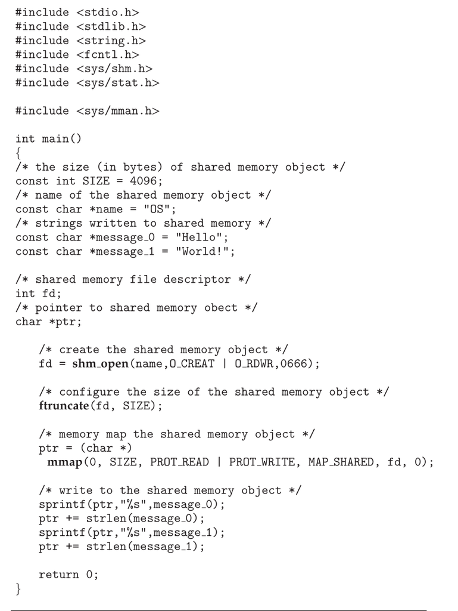

The producer's job is to create the shared memory segment and write data into it.

1. **Setup:** The program defines the size of the shared memory (`SIZE = 4096`) and a unique name for the shared object (`name = "OS"`).
2. **Creating the Shared Memory Object:**
   - `fd = shm_open(name, O_CREAT | O_RDWR, 0666);`
   - This creates a shared-memory object named "OS" with read/write permissions. The `O_CREAT` flag ensures it is created if it doesn't exist.
3. **Setting the Size:**
   - `ftruncate(fd, SIZE);`
   - This configures the size of the shared-memory object to 4096 bytes.
4. **Memory Mapping:**
   - `ptr = mmap(0, SIZE, PROT_READ | PROT_WRITE, MAP_SHARED, fd, 0);`
   - This is the critical step. It maps the shared-memory object into the producer's address space.
   - The `MAP_SHARED` flag is essential: it means that any writes to this memory region will be visible to all other processes that have mapped the same object.
5. **Writing Data:**
   - The producer writes the strings "Hello" and "World!" to shared memory using `sprintf(ptr, ...)`.
   - After writing each string, it increments the pointer `ptr` by the number of bytes written (`strlen(message_0)`). This moves the pointer forward in the shared buffer so the next write doesn't overwrite the previous one.

When the producer finishes, the shared memory contains the string "HelloWorld!". The producer then terminates, but the shared-memory object persists in the system.

#### **The Consumer Program**

**Go to Figure 3.17: Consumer process illustrating POSIX shared-memory API.**

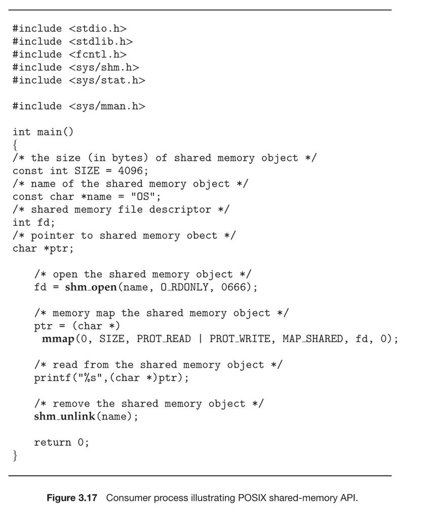

The consumer's job is to access the existing shared memory segment and read the data from it.

#### **Key Points and Omissions**

- This example is simplified. In a real producer-consumer system, you would need a **synchronization mechanism** (like a semaphore, covered in Chapter 6) to ensure the consumer doesn't try to read before the producer has finished writing. The code as shown has a **race condition**.
- The use of `shm_unlink` by the consumer is just one design choice. The producer, or a separate process, could also be responsible for cleanup.
- The text mentions that memory mapping is covered in more detail in **Section 13.5**.

### **3.7.2 Mach Message Passing**

This section explores how message passing is implemented in the Mach operating system, a highly influential microkernel that forms the core of macOS and iOS. Mach treats message passing as its fundamental mechanism for all communication.

#### **Core Concepts in Mach**

- **Tasks and Threads:** In Mach, a **task** is similar to a process but is a container that holds resources, including multiple **threads** of control.
- **Messages and Ports:** All communication in Mach is done via **messages**. Messages are sent to and received from **ports**, which are Mach's name for mailboxes.
  - Ports are **finite in size** (they have a bounded queue).
  - Ports are **unidirectional**. For two-way communication, you need two ports: one for sending the request and a separate **reply port** for the response.
  - A port can have **multiple senders** but only **one receiver**.

#### **Port Rights and Security**

A crucial security concept in Mach is **port rights**. A port right is a capability or permission that a task must hold to interact with a port.

- To receive from a port, a task must have the `MACH_PORT_RIGHT_RECEIVE` right.
- The task that creates a port is its **owner** and initially holds the receive right.
- Ownership can be transferred. For example, if Task T1 (owning port P1) sends a message to Task T2 and expects a reply, T1 must grant T2 the `MACH_PORT_RIGHT_SEND` right for P1 so T2 can send the reply back.

**Special Ports:** When a task is created, it gets two special ports:

1. **Task Self Port:** The task can send messages to this port to communicate with the kernel (which has the receive right).
2. **Notify Port:** The kernel sends event notifications to this port (the task has the receive right).

#### **Creating a Port and Sending/Receiving Messages**

The `mach_port_allocate()` system call is used to create a new port and allocate its message queue. The following code example creates a port:

```
mach_port_t port; // This is the name (an integer) for the port right
mach_port_allocate(
    mach_task_self(),      // A reference to the current task
    MACH_PORT_RIGHT_RECEIVE, // The right to create for this port
    &port);                // Where to store the port name
```

- Port names are simple integers, similar to UNIX file descriptors.

**The Bootstrap Server:** Tasks also have a **bootstrap port**. This allows a task to register a port it created with a system-wide **bootstrap server**. Other tasks can then look up this port by name in the registry to obtain send rights, enabling discovery and communication between unrelated tasks.

#### **Message Queues and Message Structure**

- Each port has a finite-sized queue. Messages are copied into this queue when sent.
- Delivery is **reliable** and all messages have the same priority.
- Mach guarantees **FIFO order for messages from the same sender**, but not for messages from different senders (they may be interleaved).

A Mach message consists of two parts:

1. **A Fixed-Size Header:** Contains metadata like the message size and the source and destination ports. The source port acts as a "return address" for replies.
2. **A Variable-Sized Body:** Contains the actual data.

Messages can be of two types:

- **Simple Messages:** Contain ordinary, unstructured user data. The kernel does not interpret this data.
- **Complex Messages:** Can contain:
  - **Out-of-line data:** Pointers to memory locations containing the actual data. This is highly efficient for large data, as it avoids the cost of copying the entire data into the message; only the pointer is sent.
  - **Port rights:** Used to transfer capabilities to another task.

#### **The Unified API: `mach_msg()`**

Mach uses a single function for both sending and receiving messages: `mach_msg()`. A parameter passed to this function specifies the operation:

- `MACH_SEND_MSG`: To send a message.
- `MACH_RCV_MSG`: To receive a message.

This unified API simplifies the message-passing interface.

#### **Code Example: Client-Server Communication**

**Go to Figure 3.18: Example program illustrating message passing in Mach.**

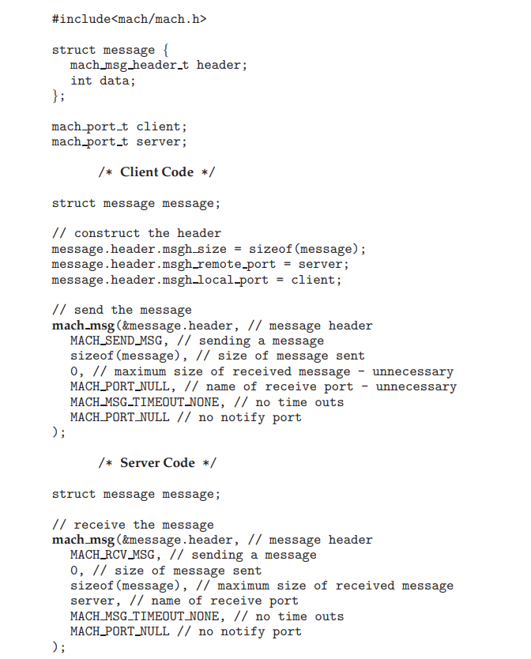

The example shows how a client task sends a message to a server task using two ports: a `client` port and a `server` port.

**Client Code (The Sender):**

1. **Message Structure:** The message is defined as a struct containing a header (`mach_msg_header_t`) and the data (`int data`).
2. **Construct the Header:** The client fills out the message header:
   - `msgh_size`: The total size of the message.
   - `msgh_remote_port`: The destination port (the `server` port).
   - `msgh_local_port`: The source port (the `client` port), which the server will use as the "return address" for its reply.
3. **Send the Message:** The client calls `mach_msg()` with the `MACH_SEND_MSG` flag. The parameters specify the message header, the send operation, the size of the outgoing message, and various options (here, no timeouts and no special notify port).

**Server Code (The Receiver):**

1. **Receive the Message:** The server calls `mach_msg()` with the `MACH_RCV_MSG` flag.
2. **Parameters for Receiving:** It specifies the `server` port as the port to receive from and provides the size of the buffer (`sizeof(message)`) where the incoming message should be stored.

**The Kernel's Role:** The user-level `mach_msg()` function calls `mach_msg_trap()`, which is a system call that switches to the kernel. The kernel then calls `mach_msg_overwrite_trap()` to handle the actual, low-level work of moving the message.

#### **Flexible Send Operations and Handling Full Queues**

A key feature of Mach is the flexibility in how it handles a `send()` operation when the destination port's queue is full. The sender can specify its behavior via parameters to `mach_msg()`:

1. **Wait indefinitely** until space becomes available in the queue.
2. **Wait for a maximum of *n* milliseconds** before timing out.
3. **Do not wait at all**; return immediately with an error.
4. **Temporarily cache the message.** This advanced option is designed for servers. The kernel takes ownership of the message and will deliver it when space is available, sending a notification back to the original sender. This allows a server to continue processing other requests even if one client's reply port is full, without being blocked.

#### **Performance Optimization: Avoiding Copying**

A major historical drawback of message-passing systems is performance loss from copying data from the sender's memory space to the kernel, and then again from the kernel to the receiver's memory space.

Mach uses a clever optimization to avoid this:

- It uses **virtual-memory-management techniques** (covered in Chapter 10). Instead of copying the data, the kernel simply **remaps the memory pages** containing the message from the sender's address space into the receiver's address space.
- This means both the sender and receiver are accessing the **same physical memory** for the message body, eliminating the costly copy operations.

**Important Limitation:** This high-performance technique **only works for messages within a single system** (intrasystem). It cannot be used for messages sent over a network to a different computer in a distributed system. This optimization is a primary reason for Mach's high-performance IPC.

### **3.7.3 Windows Inter-Process Communication (IPC)**

This section explains how different programs and system components communicate within the Windows operating system. The design is modular, meaning it's built from separate, well-defined parts (modules) that talk to each other. This makes the system more powerful and easier to update.

#### **The Client-Server Model and Subsystems**

In Windows, application programs (like your web browser or a game) often don't talk directly to the operating system kernel. Instead, they communicate with **subsystems**. A subsystem is a part of the OS that provides a specific environment or set of services. For example, one subsystem might manage the graphical user interface, while another handles security.

- **Application programs** act as **clients**.
- **Subsystems** act as **servers**.
- They communicate using a **message-passing mechanism**. The client sends a request message to the server, and the server sends back a reply message.

#### **The Advanced Local Procedure Call (ALPC)**

The specific message-passing facility in Windows is called the **Advanced Local Procedure Call (ALPC)**. It's designed for communication between two processes *on the same computer*.

- **Think of it like this:** It's similar to a Remote Procedure Call (RPC), which is a way for a program to call a function on another machine across a network. However, ALPC is a highly optimized version used only for communication within a single Windows machine.

#### **How ALPC Establishes a Connection: Ports and Channels**

ALPC uses objects called **ports** to manage connections, similar to the Mach operating system.

1. **Connection Port:** A server process creates and "publishes" a **connection-port object** that other processes can see. It's like the server putting up a public "Now Open for Business" sign.
2. **Connection Request:** A client process that needs a service finds this connection port and sends a connection request. It's like a customer walking up to the front desk.
3. **Communication Channel:** When the server accepts the request, it creates a private, two-way **communication channel** just for that client. This channel is made up of a pair of private **communication ports**:
   - One port for sending messages from the client to the server.
   - One port for sending replies from the server back to the client.
   - The server gives the client a "handle" (a reference) to this new channel.

This process is illustrated in **Figure 3.19**. The client connects to the server's public **Connection Port**. Once connected, they get handles to a private, two-way channel made of **Communication Ports**.

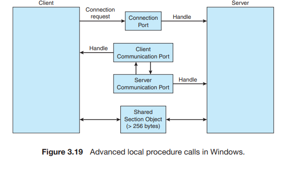

#### **ALPC Message-Passing Techniques**

ALPC is smart and uses one of three different methods to pass data, depending on the size of the message. This is done for efficiency.

1. **For Small Messages (up to 256 bytes):**
   - **Method:** The message is copied directly into a queue in the port's memory.
   - **Analogy:** Like passing a short, handwritten note to someone. It's quick and simple to copy the information.
2. **For Larger Messages:**
   - **Method:** Uses a **section object**, which is a block of **shared memory** that both the client and server can access.
   - **How it works:** The sender places the large message into the shared memory section. Then, it sends a very small message via the port (using method #1) that contains a *pointer* to where the data is located in the shared section. The receiver uses this pointer to read the data directly.
   - **Why it's better:** This avoids the slow process of copying the entire large message from one process's memory to another's. It's like telling someone, "I've left the big report for you on the shared desk, here's exactly where to find it," instead of photocopying the entire 100-page report.
3. **For Very Large Amounts of Data:**
   - **Method:** The server is given special permission to read from or write directly into the client process's own memory (its address space).
   - **Use Case:** This is the most complex method and is used when the data is too large or doesn't fit well into the shared section object method.

**Important Setup Note:** The client must decide upfront when creating the channel if it will need to send large messages. If so, it requests that a section object (shared memory) be created for the channel.

#### **Key Takeaway: Who Uses ALPC?**

It is crucial to understand that application programmers **do not** use ALPC directly. It is not part of the standard Windows API that programmers use.

- Instead, applications use standard **Remote Procedure Calls (RPC)**.
- When an RPC call is made to a process on the *same machine*, Windows internally and automatically translates that RPC into an **ALPC** for fast, local execution.
- Furthermore, many core Windows kernel services use ALPC to communicate with client processes. So, while you don't see it, ALPC is a fundamental mechanism making Windows run smoothly.

### **3.7.4 Pipes**

A **pipe** is one of the most fundamental Inter-Process Communication (IPC) mechanisms. Think of it like a real-world water pipe: it acts as a conduit or a channel that allows data to flow from one process to another. Pipes were one of the very first IPC methods in early UNIX systems and remain popular because they provide a relatively simple way for processes to exchange information, though they do have some limitations.

When we talk about implementing or using a pipe, there are four key design questions we need to consider:

#### **Four Key Issues in Pipe Implementation**

1. **Direction of Communication:**
   - Is the pipe **unidirectional** (data flows only in one direction, like a one-way street)?
   - Or is it **bidirectional** (data can flow in both directions)?
2. **Mode of Two-Way Communication:**
   - If the pipe is bidirectional, is it **half-duplex** (data can travel in both directions, but only in one direction at a time, like a walkie-talkie)?
   - Or is it **full-duplex** (data can travel in both directions simultaneously, like a telephone call)?
3. **Relationship Between Processes:**
   - Must the communicating processes have a specific relationship? For example, must one be the **parent** process and the other be its **child** process?
4. **Network Communication:**
   - Can the pipe be used for communication between processes on **different machines** over a network?
   - Or are the processes restricted to residing on the **same machine**?

#### **Types of Pipes**

In the following sections, we will explore two common types of pipes that are used on both UNIX/Linux and Windows systems. These are:

- **Ordinary Pipes:** The simpler, more basic form.
- **Named Pipes:** A more advanced and flexible version.

We will examine how each of these pipe types addresses the four key issues listed above.

#### **3.7.4.1 Ordinary Pipes**

This section dives into the first and simpler type of pipe: the **Ordinary Pipe**.

##### **Concept and Behavior**

Ordinary pipes work in a classic **producer-consumer** fashion.

- One process, the **producer**, writes data into one end of the pipe (the **write end**).
- The other process, the **consumer**, reads that data from the other end (the **read end**).

Because of this design, ordinary pipes have a critical characteristic: they are **unidirectional**. Data can only flow in one single direction.

- **What if you need two-way communication?** You must create **two separate pipes**. One pipe would handle communication from Process A to Process B, and the second, separate pipe would handle communication from Process B back to Process A.

Let's look at how this is implemented in UNIX and Windows.

##### **Ordinary Pipes in UNIX Systems**

On UNIX and Linux systems, you create an ordinary pipe using the `pipe()` system call.

**The `pipe(int fd[])` Function:**

- This function creates a pipe and returns two **file descriptors** (integers that represent open files/I/O channels) in the `fd[]` array.
- **`fd[0]`** is the **read end** of the pipe. You use this descriptor to read data from the pipe.
- **`fd[1]`** is the **write end** of the pipe. You use this descriptor to write data into the pipe.

Since UNIX treats everything as a file, a pipe is considered a special type of file. This means you use the standard `read()` and `write()` system calls to interact with it, using the file descriptors `fd[0]` and `fd[1]`.

**A Key Limitation: The Process Relationship** An ordinary pipe **cannot be accessed from outside the process that created it**. It is private to its creator. The typical way to use it is:

1. A **parent process** creates the pipe using `pipe()`.
2. The parent then creates a **child process** using the `fork()` system call.
3. Because the child process inherits all open file descriptors from its parent (as discussed in Section 3.3.1), it automatically has access to the same pipe.

**Go to Figure 3.20:** This figure illustrates the file descriptors for an ordinary pipe after a `fork()`. Both the parent and child have their own copies of the `fd[]` array, pointing to the same underlying pipe. The parent can write to `fd[1]`, and the child can read that same data from `fd[0]`.

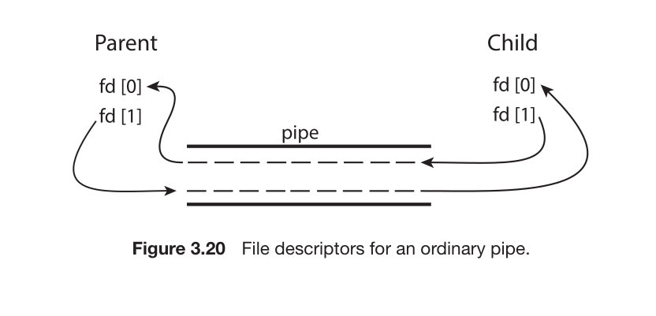

**Code Example Walkthrough:**

**Go to Figure 3.21:** This C code shows the setup for a UNIX ordinary pipe.

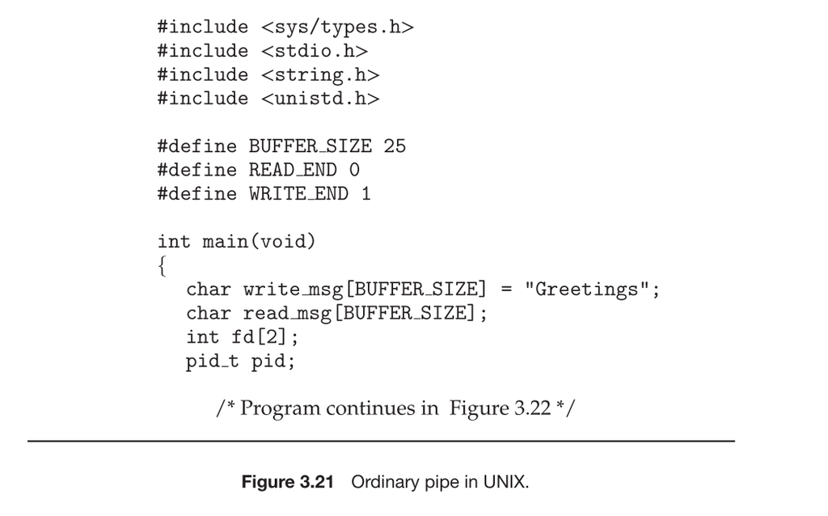

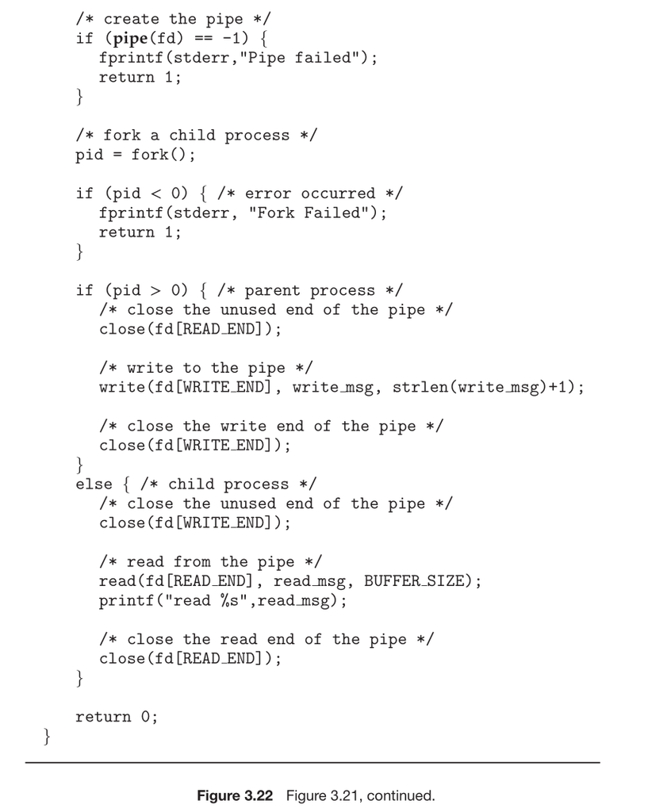

Let's break down what the code in Figure 3.21 does:

1. It includes necessary header files.
2. It defines a buffer size and two constants for clarity: `READ_END` (0) and `WRITE_END` (1).
3. It declares two character arrays for the messages and an integer array `fd[2]` to hold the two file descriptors for the pipe.
4. It declares a variable `pid` to store the process ID returned by `fork()`.

**What happens after `fork()`?** After the child process is created, both the parent and child run simultaneously. In this specific example, the plan is:

- The **parent process** will write the message "Greetings" to the pipe.
- The **child process** will read the message from the pipe.

**A Critical Step: Closing Unused Ends** The text highlights a very important practice: **both processes must close the ends of the pipe they are not using.**

- The parent, which is only writing, should close its read end (`fd[0]`).
- The child, which is only reading, should close its write end (`fd[1]`).

**Why is this so important?**

- It ensures that the `read()` system call behaves correctly. The `read()` function will return a `0` (indicating an "end-of-file" condition) only when *all* write ends of the pipe are closed.
- If the child did not close its write end, there would still be an open write descriptor on the pipe. If the parent finished writing and closed its end, the child's `read()` call would *not* return `0` because it would still be possible for *the child itself* to write to the pipe. This would leave the child process waiting for more data that will never come, causing a potential hang.
- Closing unused ends is crucial for proper coordination and detecting when the communication is finished.

##### **Ordinary Pipes on Windows Systems**

This section continues the discussion of ordinary pipes by explaining their implementation in the Windows operating system, where they are known as **Anonymous Pipes**.

##### **Concept and Behavior in Windows**

Windows anonymous pipes are conceptually very similar to UNIX ordinary pipes:

- They are **unidirectional** (one-way communication).
- They require a **parent-child relationship** between the communicating processes.
- Data is written using a standard write function (`WriteFile`) and read using a standard read function (`ReadFile`).

##### **The Windows API: `CreatePipe()`**

The key function for creating an anonymous pipe in Windows is `CreatePipe()`. This function is passed four parameters that define the pipe's properties:

1. **`hReadPipe`**: A handle (a Windows reference to an object) for **reading** from the pipe.
2. **`hWritePipe`**: A handle for **writing** to the pipe.
3. **`lpPipeAttributes`**: A pointer to a `SECURITY_ATTRIBUTES` structure. This is crucial because it allows the programmer to specify whether the pipe handles can be **inherited** by a child process.
4. **`nSize`**: The suggested size, or buffer capacity, of the pipe (in bytes). The system may use this as a guideline but is not required to create a pipe of exactly this size.

##### **Key Difference: Explicit Handle Inheritance**

A major difference from UNIX is that Windows does **not** automatically inherit all open handles/file descriptors.

- In UNIX, after a `fork()`, the child automatically gets a copy of the parent's file descriptors, including the pipe ends.
- In Windows, the programmer must **explicitly specify** which handles the child process is allowed to inherit. This is a deliberate, security-conscious design.

**How is this done?**

1. The programmer initializes a `SECURITY_ATTRIBUTES` structure and sets `bInheritHandle = TRUE`.
2. This structure is then passed to the `CreatePipe()` function.
3. Furthermore, the parent process must redirect the child's standard input or output to the pipe handle. In the example from **Figure 3.23**, the parent wants the child to read from the pipe. Therefore, it redirects the child's **standard input (`STD_INPUT_HANDLE`)** to the *read handle* of the pipe.
4. Because the pipe is half-duplex (unidirectional), the parent must also ensure the child does **not** inherit the *write end* of the pipe. This prevents the child from accidentally writing to the same pipe it's reading from, which could cause confusion or deadlock.

##### **Code Example Walkthrough**

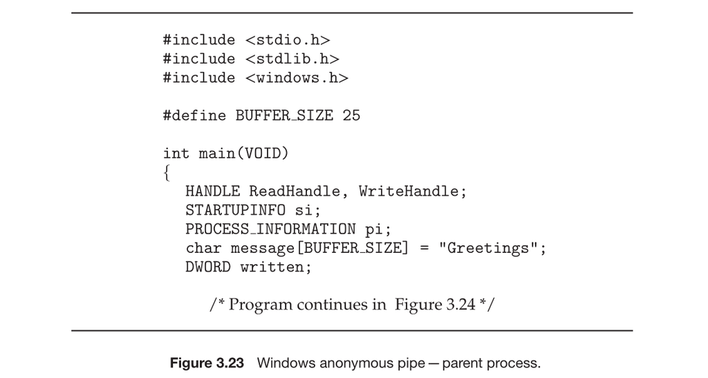

**Go to Figure 3.23:** This C code shows the initial setup for a Windows anonymous pipe in the parent process.

Let's break down what the code in Figure 3.23 does:

1. It includes the Windows header file `<windows.h>`.
2. It declares two `HANDLE` variables: `ReadHandle` and `WriteHandle`. These will be the handles to the two ends of the pipe.
3. It declares a `STARTUPINFO` structure (`si`) and a `PROCESS_INFORMATION` structure (`pi`). These are required by Windows to create and manage the new child process.
4. It defines the message buffer and a `DWORD` variable `written` to track how many bytes were written.

**Go to Figure 3.22 (for context):** While Figure 3.22 shows the UNIX code completion, the logical flow for Windows is analogous but uses different API calls. After the setup in Figure 3.23, the parent process would:

1. Call `CreatePipe` with the appropriate security attributes to allow handle inheritance.
2. Use `CreateProcess` to launch the child process (similar to the program in Figure 3.10), setting the `bInheritHandles` parameter to `TRUE`.
3. The parent would then **close its unused end** of the pipe (in this case, the read end) before writing to the pipe using `WriteFile(WriteHandle, ...)`.

- The child process does not receive the pipe handle as a direct parameter. Instead, because the parent redirected the child's standard input, the child can obtain the read handle by calling `GetStdHandle(STD_INPUT_HANDLE)`.
- It can then read from this handle using the standard `ReadFile()` function.

##### **Summary of Limitations for Ordinary Pipes**

The text concludes by reiterating the core limitations of ordinary (anonymous) pipes, which apply to **both UNIX and Windows** systems:

1. **Relationship Requirement:** They require a **parent-child relationship** between the communicating processes. You cannot use an ordinary pipe to connect two unrelated processes that started independently.
2. **Machine Scope:** Because of this relationship requirement, ordinary pipes can **only be used for communication between processes on the same machine**. They cannot be used for network communication.

#### **3.7.4.2 Named Pipes**

This section introduces a more powerful and flexible IPC mechanism: **Named Pipes**.

##### **Limitations of Ordinary Pipes Recap**

First, let's recall the shortcomings of ordinary pipes that named pipes are designed to overcome:

- They are **temporary**. The pipe only exists while the communicating processes are running.
- They require a **parent-child relationship** between the processes.
- They are **unidirectional**.

##### **Advantages of Named Pipes**

Named pipes provide a much more powerful and flexible communication tool. Their key features are:

1. **Persistence:** A named pipe continues to exist in the system **after the communicating processes have finished**. It must be explicitly deleted, like a file.
2. **No Parent-Child Relationship:** Processes do not need to be related. Any process that knows the name of the pipe can use it to communicate.
3. **Multiple Writers:** Several processes can use the same named pipe for communication. In a typical scenario, a named pipe can have **several writers**.
4. **Bidirectional Communication Potential:** While the specifics vary by OS, named pipes can support bidirectional communication.

Both UNIX and Windows systems support named pipes, but their implementations differ significantly.

##### **Named Pipes in UNIX (FIFOs)**

In UNIX and Linux systems, named pipes are called **FIFOs** (First-In, First-Out).

**Creation and Management:**

- A FIFO is created using the `mkfifo()` system call.
- Once created, it appears as a **special type of file** in the file system (you can see it with the `ls` command).
- It is manipulated using the standard file operations: `open()`, `read()`, `write()`, and `close()`.
- It is **persistent**: it remains in the file system until it is explicitly deleted using the `unlink()` system call, just like a regular file.

**Communication Characteristics:**

- **Bidirectional?** FIFOs allow bidirectional communication in the sense that a process can open a FIFO for both reading and writing. However, the transmission is typically **half-duplex**. This means data can travel in both directions, but **not at the same time**.
- **Solution for Full-Duplex:** If you need simultaneous two-way communication, you must create **two FIFOs** (e.g., one called `fifo_AtoB` and another called `fifo_BtoA`).
- **Network Communication?** No. The communicating processes **must reside on the same machine**.
- **Data Type:** UNIX FIFOs can only transmit **byte-oriented data** (a continuous stream of bytes).

##### **Named Pipes in Windows Systems**

Named pipes on Windows provide a richer and more feature-complete communication mechanism than UNIX FIFOs.

**Creation and Connection:**

- A server creates a named pipe using the `CreateNamedPipe()` function.
- A client process connects to an existing named pipe using the `ConnectNamedPipe()` function (on the server side) and `CreateFile()` on the client side.
- Communication is performed using the standard `ReadFile()` and `WriteFile()` functions.

**Advanced Communication Characteristics:**

- **Bidirectional?** Yes. Windows named pipes support **full-duplex communication**. Data can travel in both directions **simultaneously** over the same pipe.
- **Network Communication?** Yes. This is a major advantage. The communicating processes may reside on **either the same machine or different machines** across a network.
- **Data Type:** Windows systems are more flexible. They allow the transmission of either **byte-oriented data** (a stream of bytes) or **message-oriented data** (discrete messages with boundaries preserved). This is specified when the pipe is created.
- **Multiple Clients:** A single Windows named pipe server can handle connections from multiple client processes.

##### **Summary Table: Ordinary Pipes vs. Named Pipes**

| Feature | Ordinary Pipes (UNIX & Windows) | Named Pipes (UNIX FIFOs) | Named Pipes (Windows) |
| --- | --- | --- | --- |
| **Persistence** | Temporary (lasts only while processes run) | Persistent (exists until deleted) | Persistent (exists until deleted) |
| **Process Relationship** | Required (Parent-Child) | **Not Required** | **Not Required** |
| **Direction** | Unidirectional | Half-Duplex (typically) | **Full-Duplex** |
| **Network Use** | No (same machine only) | No (same machine only) | **Yes (same or different machines)** |
| **Data Type** | Byte-oriented | Byte-oriented | Byte- or Message-oriented |

## **3.8 Communication in Client–Server Systems**

This section expands on the topic of Inter-Process Communication (IPC) by focusing specifically on techniques used in **client–server systems**. As a reminder from Section 1.10.3, this is a common architecture where a **server** process provides a service, and a **client** process requests that service.

#### **Recap and Introduction**

Previously, in Section 3.4, we learned about two fundamental IPC techniques:

1. **Shared Memory**
2. **Message Passing**

Both of these techniques can be, and are, used to facilitate communication in client-server systems. In this section, we will explore two other, highly important strategies designed for this purpose:

1. **Sockets**
2. **Remote Procedure Calls (RPCs)**

The text also notes that RPCs are not only useful for classic network communication but are also used by the Android operating system as a form of IPC between processes *on the same device*.

### **PIPES IN PRACTICE**

Before diving into sockets and RPCs, the text provides a practical, real-world example of how pipes are used every day in command-line environments.

#### **The UNIX/Linux Example**

In UNIX, pipes are frequently used on the command line to chain commands together, where the output of one command becomes the input for the next. This is a direct application of the producer-consumer model.

- **Scenario:** The `ls` command lists all files in a directory. If there are many files, the output scrolls by too fast to read. The `less` command is a "pager" that displays output one screen at a time, allowing you to scroll up and down.
- **The Solution:** You can connect these two commands using a pipe.
- **The Command:** `ls | less`
- **How it works:**
  - The shell creates an **ordinary pipe**.
  - It then forks two processes: one for `ls` and one for `less`.
  - The standard output (stdout) of the `ls` process (the **producer**) is connected to the write end of the pipe.
  - The standard input (stdin) of the `less` process (the **consumer**) is connected to the read end of the pipe.
  - The `ls` command produces the directory listing and writes it into the pipe. The `less` command reads this data from the pipe and displays it interactively.
- The pipe symbol on the command line is the vertical bar: **`|`**.

#### **The Windows DOS Shell Example**

The same concept applies to the Windows command prompt (DOS shell).

- **Scenario:** The `dir` command produces a directory listing. The `more` command provides functionality similar to UNIX's `less`, pausing output after each screenful.
- **The Command:** `dir | more`
- **How it works:** The mechanism is identical to the UNIX example. The shell creates an anonymous pipe, connecting the stdout of `dir` to the stdin of `more`.
- **A Note on Naming:** The text points out that UNIX also has a `more` command, but a command named `less` was created that offers more features (like scrolling backwards). The joke is that "less is more," meaning the `less` command provides *more* functionality than the `more` command.

### **3.8.1 Sockets**

This section explains one of the most fundamental networking concepts: **Sockets**.

#### **What is a Socket?**

A **socket** is defined as an **endpoint for communication**. When two processes need to communicate over a network, each process uses a socket. Therefore, a connection consists of a **pair of sockets**—one for each process involved.

A socket is uniquely identified by combining two pieces of information:

- **IP Address:** The network address of the computer (e.g., `146.86.5.20`).
- **Port Number:** A number that specifies a particular service or application on that computer (e.g., `80` for a web server).

The full socket address is written as **`IP-Address:Port-Number`** (e.g., `146.86.5.20:1625`).

#### **The Client-Server Architecture and Ports**

Sockets operate on a standard client-server model:

- The **server** process "listens" for incoming connection requests on a specific, well-known **port number**. This is like a business having a public phone number.
  - **Well-known ports** (numbers less than 1024) are reserved for standard services. Examples include:
    - Port **22**: SSH
    - Port **21**: FTP
    - Port **80**: HTTP (Web Server)
- The **client** process initiates a connection request. When it does, its host computer assigns it a port number. This client port is an **ephemeral port**, which is an arbitrary number greater than 1024. It's like the client using a private, temporary phone line to make the call.

#### **Establishing a Connection: A Detailed Example**

Let's walk through the example from the text:

1. **The Server:** A web server is running on a machine with IP address `161.25.19.8`. It is listening for connections on its well-known port, **port 80**. Its socket is `(161.25.19.8:80)`.
2. **The Client:** A client process on a machine with IP address `146.86.5.20` wants to connect to that web server.
3. **The Connection:** The client's host machine assigns it an available ephemeral port, say **port 1625**. The client's socket is now `(146.86.5.20:1625)`.
4. **The Unique Pair:** The total connection between the client and the server is defined by the unique pair of sockets: `(146.86.5.20:1625)` and `(161.25.19.8:80)`.

**Go to Figure 3.26:** This figure illustrates this exact scenario. It shows host X (`146.86.5.20`) with its client socket on port 1625, communicating with the web server (`161.25.19.8`) on its server socket, port 80. All network packets are delivered to the correct process based on the destination port number.

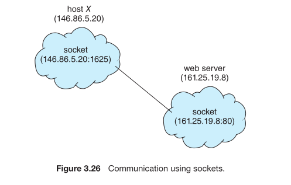

**Connection Uniqueness:** If another process on the same client host (`146.86.5.20`) also wanted to connect to the same web server (`161.25.19.8:80`), it would be assigned a different ephemeral port (e.g., 1626). This ensures that every connection on the network is a unique socket pair.

#### **Socket Programming in Java**

The text notes that while many examples in the book use C, it will use Java for sockets because Java provides a cleaner, easier-to-understand interface.

Java provides three main socket types:

1. **`Socket` (Connection-oriented):** Uses the TCP protocol. Reliable, guarantees delivery and order of data.
2. **`DatagramSocket` (Connectionless):** Uses the UDP protocol. Unreliable, but faster. No guarantee of delivery or order.
3. **`MulticastSocket` (A subclass of `DatagramSocket`):** Allows data to be sent to multiple recipients at once.

#### **Example: A Date Server using TCP Sockets**

The text provides a complete example of a simple **date server** using a connection-oriented TCP socket. The server listens on port 6013 and, when a client connects, it sends the current date and time and then closes the connection.

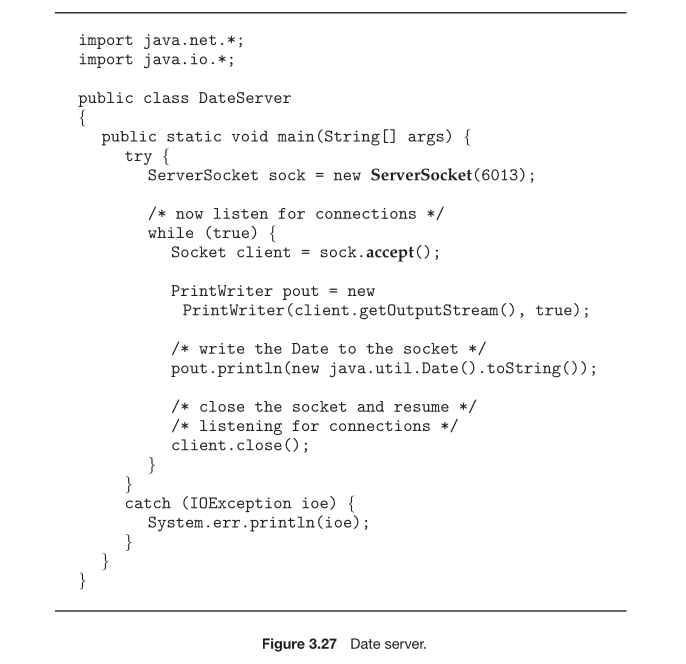

**Go to Figure 3.27:** This is the Java code for the Date Server.

Let's break down how this server works, step-by-step:

1. **Import Libraries:** The code imports `java.net.*` (for networking) and `java.io.*` (for input/output).
2. **Create a Server Socket:** The line `ServerSocket sock = new ServerSocket(6013);` creates a `ServerSocket` object that is bound to **port 6013**. This is the socket that will listen for incoming client connections.
3. **Listen for Connections (The Main Loop):** The server enters an infinite `while (true)` loop to continuously handle clients.
4. **Accept a Client Connection:** The line `Socket client = sock.accept();` is crucial. The `accept()` method **blocks**—meaning the server process waits here and does nothing else—until a client requests a connection. When a connection request arrives, `accept()` returns a new `Socket` object named `client`. This `client` socket is the dedicated communication channel to that specific client.
5. **Establish an Output Stream:** The server creates a `PrintWriter` object named `pout` that is linked to the output stream of the `client` socket (`client.getOutputStream()`). The `true` parameter enables **auto-flushing**, meaning data is sent immediately without waiting for a buffer to fill up. This `PrintWriter` allows the server to use familiar `print()` and `println()` methods to send data to the client.
6. **Send the Date:** The server gets the current date and time (`new java.util.Date().toString()`) and sends it to the client by calling `pout.println()`.
7. **Close the Client Connection:** The server calls `client.close()`, which terminates the connection with this specific client.
8. **Repeat:** The loop continues, and the server goes back to the `accept()` method to wait for the next client connection.

This example clearly illustrates the lifecycle of a simple server: **Create, Listen, Accept, Process, Close, Repeat.**

#### **The Date Client and Socket Communication Analysis**

This section completes the socket example by presenting the client's code and then discusses the overall characteristics of socket-based communication.

##### **The Date Client**

For the date server to be useful, we need a client program to connect to it and display the date it sends. The client's role is to initiate the connection and read the data.

**Go to Figure 3.28:** This is the Java code for the Date Client.

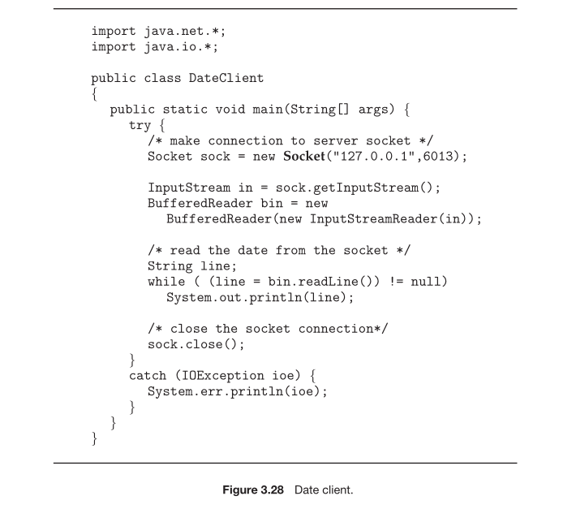

Let's break down how this client works, step-by-step:

1. **Import Libraries:** The client imports the same `java.net.*` and `java.io.*` libraries as the server for networking and I/O.
2. **Create and Connect a Socket:** The critical line is `Socket sock = new Socket("127.0.0.1", 6013);`. This single line does two things:
   - It creates a client-side `Socket` object.
   - It immediately attempts to establish a connection to the server located at IP address `127.0.0.1` on port `6013`.
3. **The Loopback Address (127.0.0.1):** This is a special IP address known as the **loopback address**. When a computer uses this address, it is communicating with itself. This allows you to run both the client and server on the same machine for testing. This address could be replaced with:
   - The actual IP address of another machine on the network running the server.
   - A hostname (like `www.westminstercollege.edu`), which the system automatically resolves to an IP address.
4. **Establish an Input Stream:** Once connected, the client gets an `InputStream` from the socket (`sock.getInputStream()`) and wraps it in a `BufferedReader`. This `BufferedReader` (named `bin`) allows the client to read data from the server line by line using the `readLine()` method, which is a convenient high-level operation.
5. **Read from the Server:** The client enters a `while` loop, reading each line of text sent by the server. In this simple case, the server only sends one line (the date string). The loop reads this line and prints it to the console (`System.out.println(line)`).
6. **Close the Connection:** After receiving and printing the data, the client closes its socket (`sock.close()`) and exits.

##### **Analysis of Socket Communication**

The text concludes the discussion on sockets by evaluating their place in distributed programming.

- **Common and Efficient:** Socket communication is widely used and is a performant method for network communication.
- **Low-Level Form of Communication:** Despite their usefulness, sockets are considered a **low-level** mechanism. This is because they only provide a channel for an **unstructured stream of bytes** to be exchanged.

**The Problem with Unstructured Bytes:** It is the sole responsibility of the application programmer (both the client and server developer) to **impose a structure and meaning** on this raw byte stream. For example:

- How does the server know how long the client's request message is?
- How does the client know how much data the server is going to send back?
- If multiple pieces of data are sent, how are they separated?

The programmer must design and implement a custom **application-level protocol** to handle these issues, which can be complex and error-prone.

**Conclusion:** Because of this low-level, unstructured nature, the text now introduces a **higher-level method of communication** that abstracts away these complexities: **Remote Procedure Calls (RPCs)**.

### **3.8.2 Remote Procedure Calls (RPC)**

This section introduces **Remote Procedure Calls (RPC)**, a high-level communication paradigm designed to make network communication feel as simple as calling a local function.

#### **The RPC Paradigm**

RPC is one of the most common forms of remote service. Its primary goal is to **abstract** the complex details of network communication. It makes a procedure (or function) call on a remote machine look and feel, to the programmer, just like a procedure call on the local machine.

- **Foundation:** It is conceptually similar to the message-passing IPC mechanism from Section 3.4 and is often built on top of such a system.
- **Key Difference:** Because the processes are on separate systems, it must use a **message-based communication scheme** over the network.

#### **Structured Messages and the RPC Daemon**

Unlike the unstructured byte streams of sockets, RPC communication uses **well-structured messages**.

- **Addressing:** Each message is addressed to an **RPC daemon**—a special server process—listening on a specific **port** on the remote system.
- **Message Content:** The message doesn't just contain raw data; it contains a structured request specifying:
  1. An **identifier** for the specific function to execute.
  2. The **parameters** to pass to that function.
- **Execution:** The RPC daemon receives the message, executes the specified function with the given parameters, and sends back any output in a separate reply message.

**Ports Revisited:** In this context, a port is a number within a system's network address that differentiates between its many network services. For example, a service for listing current users might be attached to port 3027. A client sends an RPC request to that port to get the user list.

#### **The Client-Server Stubs and Marshaling**

The "magic" that makes a remote call look local is achieved using **stubs** on both the client and server sides.

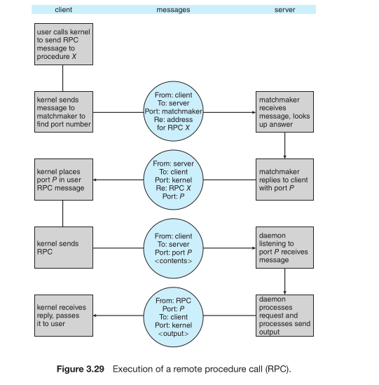

1. **Client Stub:** When a client program calls what it thinks is a local procedure, it is actually calling a **client-side stub**. This stub is a local function that represents the remote procedure.
   - The client stub's job is to **marshal the parameters**. This means it takes the procedure's parameters and packages them into a well-structured network message.
   - It then uses message passing (e.g., sockets) to send this message to the server.
2. **Server Stub:** On the server side, a **server-side stub** is waiting for incoming requests.
   - It receives the network message.
   - It **unmarshals the parameters**, extracting them from the message.
   - It then calls the *actual* server procedure on the server's machine.
3. **Returning the Result:** After the server procedure finishes, the return values are sent back to the client by reversing the process: the server stub marshals the return values, and the client stub unmarshals them and returns them to the client program.

**Microsoft Interface Definition Language (MIDL):** On Windows systems, this stub code is not written by hand. Instead, programmers write a specification in MIDL, which is then compiled to automatically generate the client and server stubs.

#### **Key Technical Challenges in RPC**

RPC systems must solve several difficult problems introduced by the network:

**1. Parameter Marshaling and Data Representation:**

- **Problem:** Different machines can represent data differently (e.g., **big-endian** vs. **little-endian** byte order for integers).
- **Solution:** The RPC system defines a **machine-independent data representation**, such as **External Data Representation (XDR)**. The client stub converts local data into XDR before sending; the server stub converts XDR into its local format upon receipt.

**2. Call Semantics:** Local calls are "exactly once." Due to network errors, RPCs can fail or be duplicated. RPC systems must define their semantics:

- **At Most Once:** The system ensures that even if multiple duplicate requests are sent, the procedure is executed *no more than once*. This is often implemented by having the server keep a history of processed requests (e.g., using timestamps) and ignoring duplicates.
- **Exactly Once:** This is the ideal, but hardest to achieve. It requires the "at most once" mechanism *plus* a system of acknowledgements (ACKs). The client must resend the request until it receives an ACK from the server confirming the call was received and executed.

**3. Binding (Finding the Server):** How does a client know which server port to connect to?

- **Fixed Port Addresses:** The port number is hardcoded at compile time. This is simple but inflexible.
- **Dynamic Binding (Rendezvous):** A more flexible approach uses a **rendezvous daemon** (or matchmaker) on a well-known port. The client first asks this daemon, "Where can I find service X?" The daemon replies with the port number of the correct RPC server. The client then communicates directly with that server.

#### **Application: Distributed File Systems (DFS)**

RPC is extremely useful for building distributed systems. A prime example is a **Distributed File System (DFS)**, covered in detail in Chapter 19.

- The DFS can be implemented as a set of RPC daemons.
- A client sends an RPC message to the server's DFS port. The message contains a file operation to perform, such as `read()`, `write()`, or `delete()`.
- The DFS daemon on the server executes the operation on its local file system and sends back the result (e.g., the contents of a file) in the return message.
- A request might be for a single block of a file, requiring multiple RPCs to transfer an entire file.

#### **3.8.2.1 Android RPC**

This section explains how the Remote Procedure Call (RPC) paradigm is adapted for use within a single device by the Android operating system.

##### **RPC as a Form of IPC**

While RPCs are typically used for communication between different machines in a network, they are also a powerful tool for **Inter-Process Communication (IPC)** between processes on the *same* system. Android uses this concept extensively in its **Binder framework**, which is its core IPC system.

##### **Android Application Components and Services**

To understand Android RPC, you first need to know about Android's building blocks:

- **Application Component:** A basic building block of an Android app (like an Activity, Broadcast Receiver, or **Service**).
- **Service:** An application component that runs in the **background**, with no user interface, to perform long-running operations or work for other processes. Examples include playing music or fetching data from the network without blocking the main app.
- **Binding a Service:** A client app can connect to, or **"bind"**, a service by calling the `bindService()` method. Once bound, the client and service can establish a **client-server communication** channel using either **message passing** or **RPCs**.

##### **Two IPC Methods in Android Services**

A bound service must extend the Android `Service` class and implement the `onBind()` method. This method is called when a client binds to it and determines the IPC method.

**1. Message Passing with `Messenger`:**

- The `onBind()` method returns a `Messenger` object.
- This allows the client to send **one-way messages** to the service.
- **For two-way communication:** The client must include its *own* `Messenger` in the `replyTo` field of the message it sends. The service can then use this client `Messenger` to send messages back.

**2. Remote Procedure Calls (RPC) with AIDL:** This is the more powerful and structured method, which allows the client to call methods on the service as if it were a local object.

##### **Implementing RPC with AIDL**

To provide RPCs, the service must return an interface for the remote object. This is done using the **Android Interface Definition Language (AIDL)**.

**Step 1: Define the AIDL Interface** The programmer creates a file (e.g., `RemoteService.aidl`) that defines the interface for the remote service using Java-like syntax.

```
aidl
/* RemoteService.aidl */
interface RemoteService {
    boolean remoteMethod(int x, double y);
}
```

This interface declares that there is a remote method called `remoteMethod` that takes an `int` and a `double` as parameters and returns a `boolean`.

**Step 2: Automatic Stub Generation** The Android SDK automatically uses this `.aidl` file to generate the necessary Java code, including the **client and server stubs**. This is similar to how MIDL works on Windows. The programmer does not have to write the network communication or marshaling code.

**Step 3: Server Implementation** The server (the Service) must provide a concrete implementation of the interface generated from the `.aidl` file. This implementation contains the actual logic that runs when `remoteMethod()` is called.

**Step 4: Client Invocation** When a client calls `bindService()`, the service's `onBind()` method is triggered. It returns the generated stub object to the client. The client can then use this stub to call the remote method directly:

```
RemoteService service; // This is actually the stub object
...
boolean result = service.remoteMethod(3, 0.14); // Calls the remote service
```

##### **The Role of the Binder Framework**

Internally, the **Android Binder framework** handles all the complex, low-level work transparently:

- **Parameter Marshaling:** It converts the parameters (`3` and `0.14`) into a format suitable for cross-process transmission.
- **Inter-Process Transfer:** It passes the marshaled data from the client process to the server process.
- **Method Invocation:** It invokes the correct method (`remoteMethod`) on the server's implementation object.
- **Return Value:** It marshals the return value (`result`) and sends it back to the client process.

In summary, Android RPC provides a high-level, programmer-friendly way for apps to communicate and share functionality securely, abstracting away all the underlying complexity of process boundaries and data marshaling.

## **3.9 Summary**

This chapter covered the fundamental concept of a **process** and how processes communicate with each other. Here is a concise summary of the key points.

### **1. The Process Concept**

- A **process** is a program in execution.
- Its current activity is tracked by the **program counter (PC)** and the contents of the CPU registers.
- A process in memory is divided into four sections:
  1. **Text:** The executable code.
  2. **Data:** Global variables.
  3. **Heap:** Dynamically allocated memory during runtime.
  4. **Stack:** Temporary data (function parameters, return addresses, local variables).

### **2. Process State and Management**

- A process changes **state** as it executes. The general states are:
  1. **Ready:** Waiting to be assigned to a CPU.
  2. **Running:** Instructions are being executed.
  3. **Waiting:** Waiting for some event (like I/O completion).
  4. **Terminated:** Finished execution.
- The operating system represents each process with a **Process Control Block (PCB)**, a kernel data structure containing all information about a process (PID, state, PC, etc.).
- The **process scheduler** selects from among the ready processes which one to run next on the CPU.
- A **context switch** is the operation where the kernel saves the state of the currently running process and restores the state of a new process to run.

### **3. Process Creation**

- Processes are created using system calls:
  - **UNIX/Linux:** `fork()` system call.
  - **Windows:** `CreateProcess()` function.

### **4. Interprocess Communication (IPC)**

Processes can communicate using two main models:

**A. Shared Memory**

- Two or more processes share the same region of memory.
- **POSIX** provides a standard API for setting up shared memory.

**B. Message Passing**

- Processes communicate by exchanging messages.
- **Mach** and **Windows** use message passing as a primary IPC mechanism.
  - Windows uses the **Advanced Local Procedure Call (ALPC)** facility for local message passing.

### **5. Pipes**

A pipe is a conduit for two processes to communicate. There are two types:

**A. Ordinary Pipes**

- Designed for communication between processes with a **parent-child relationship**.
- **UNIX:** Created with `pipe()`. Has a read end (`fd[0]`) and a write end (`fd[1]`).
- **Windows:** Called **Anonymous Pipes**. Created with `CreatePipe()`. Unidirectional and require a parent-child relationship.

**B. Named Pipes**

- More general; allow communication between unrelated processes.
- **UNIX:** Called **FIFOs**. Created with `mkfifo()`. Appear as files in the filesystem. Typically half-duplex.
- **Windows:** **Named Pipes**. Richer than FIFOs; support full-duplex communication and can be used over a network.

### **6. Client-Server Communication**

**A. Sockets**

- An endpoint for communication, defined by an IP address and a port number.
- Allow two processes on different machines to communicate over a network.
- Considered a **low-level** mechanism as it only provides an unstructured byte stream.

**B. Remote Procedure Calls (RPCs)**

- A high-level abstraction that makes a procedure call on a remote machine appear as a local call.
- Uses **stubs** on the client and server to handle **marshaling** (converting parameters to a network format) and communication.
- **Android RPC:** The Android OS uses a form of RPC (via its **Binder framework** and **AIDL**) for IPC between processes on the same device, allowing one process to invoke services in another.